# Exploring Perceptions and Emotions During COVID-19

### A Mixed-Data Analysis of Survey Responses and Twitter Content

## Introduction

The COVID-19 pandemic significantly altered daily life across the world, shaping public sentiment, emotional well-being, and opinions on government measures. This project presents a dual-perspective analysis by examining:

- Structured survey data collected from individuals in **Milan** and **New York**
- Unstructured social media data from **Twitter**

Using Python-based tools and libraries such as **Pandas**, **NumPy**, **Matplotlib**, **Seaborn**, **TextBlob**, and **NLTK**, this analysis explores how people *felt*, *reacted*, and *reflected* during various phases of the pandemic.

The project is organized into three key sections:

1. **Data Preprocessing**  
   Loading, cleaning, and transforming survey and Twitter datasets. Column renaming and feature engineering were essential for clarity and effective analysis.
2. **Survey Data Analysis**  
   An in-depth exploration of how demographics, living situations, and work/study conditions influenced emotional and psychological responses. Topics include:
   - Emotional well-being and living arrangements
   - Public opinion on mask mandates, lockdowns, and vaccination passes
   - Feelings and experiences after testing positive for COVID-19
   - Impact on students and professionals
   - Perceptions of returning to "normality"
   - General emotions associated with the pandemic
3. **Twitter Data Analysis**  
   Natural language processing (NLP) techniques were applied to examine sentiment and categorize emotions in real-time COVID-19 related tweets. This includes:
   - Text cleaning and preprocessing
   - Sentiment analysis using polarity and subjectivity scores
   - Emotion classification using keyword matching, WordNet expansion, and manual variation detection
   - Comparison of online sentiment with reported emotions from survey participants

```python
import matplotlib.pyplot as plt
%matplotlib inline
import numpy as np
import pandas as pd
import seaborn as sns
import warnings
sns.set_style("whitegrid")
```

# Data Set Resource

Refer to https://dataverse.harvard.edu/file.xhtml?fileId=6913780&version=1.0

```python
covid = pd.read_csv('data/dataset.csv')
covid
```

|  | City | At the beginning of the pandemic did you work or study? | Family | Friends | Pets | Roommates | People I didn't know | Alone | How many people did you live with in that period? | Bored.3c | ... | Taking public transportation.1 | Going to a crowded event outdoors.1 | Do you feel you have gone back to your “normality”? | What is your job sector? | What is your major? | What is your gender? | How old are you now? | Where did you grow up? | What is your ethnicity? | Which of these emotions do you associate with COVID-19? |
| --- | --- | --- | --- | --- | --- | --- | --- | --- | --- | --- | --- | --- | --- | --- | --- | --- | --- | --- | --- | --- | --- |
| 0 | New York | Study | Family | NaN | NaN | NaN | NaN | NaN | 3.0 | NaN | ... | 3.0 | 2.0 | 4.0 | NaN | Engineering and Technology | Male | 24-30 | I come from abroad | Asian | Stressed |
| 1 | New York | Both | Family | NaN | NaN | NaN | NaN | NaN | 2.0 | Bored | ... | 4.0 | 4.0 | 4.0 | NaN | Engineering and Technology | Female | 24-30 | I'm from somewhere else in the US | Asian | Frustrated |
| 2 | New York | Work | NaN | NaN | NaN | Roommates | NaN | NaN | 2.0 | NaN | ... | 5.0 | 5.0 | 8.0 | Information Technology | NaN | Male | 30-40 | I come from abroad | Asian | Distant |
| 3 | New York | Work | NaN | NaN | Pets | NaN | NaN | NaN | NaN | Bored | ... | 4.0 | 3.0 | 5.0 | Food & Consumer Goods | NaN | Male | 40-50 | I'm from New York State | White | Frustrated |
| 4 | New York | Work | NaN | NaN | NaN | NaN | NaN | Alone | NaN | NaN | ... | 5.0 | 5.0 | 6.0 | Food & Consumer Goods | NaN | Male | 30-40 | I'm from New York State | White | Optimistic |
| ... | ... | ... | ... | ... | ... | ... | ... | ... | ... | ... | ... | ... | ... | ... | ... | ... | ... | ... | ... | ... | ... |
| 3000 | Milan | Study | Family | NaN | NaN | NaN | NaN | NaN | 1.0 | NaN | ... | 2.0 | 4.0 | 5.0 | NaN | Built Environment and Design | Female | 24-30 | I'm Italian | White | NaN |
| 3001 | Milan | Study | Family | NaN | NaN | NaN | NaN | NaN | 2.0 | NaN | ... | 5.0 | 5.0 | 9.0 | NaN | Commerce, Management, Tourism and Services | Male | 20-24 | I'm Italian | White | NaN |
| 3002 | Milan | Work | Family | NaN | NaN | NaN | NaN | NaN | 3.0 | NaN | ... | 1.0 | 5.0 | 4.0 | Other / I prefer not to answer | NaN | Female | 50-60 | I'm Italian | White | NaN |
| 3003 | Milan | Work | Family | NaN | NaN | NaN | NaN | NaN | 3.0 | NaN | ... | 3.0 | 5.0 | 9.0 | Information Technology | NaN | Male | 50-60 | I'm Italian | White | NaN |
| 3004 | Milan | Study | Family | NaN | NaN | NaN | NaN | NaN | 3.0 | NaN | ... | 3.0 | 5.0 | 7.0 | NaN | Studies in Human Society | Male | 18-20 | I come from abroad | White | NaN |

3005 rows × 123 columns

```python
warnings.simplefilter(action='ignore', category=FutureWarning)
```

## Checking information of Covid Data Frame

```python
covid.info()
```

```
<class 'pandas.core.frame.DataFrame'>
RangeIndex: 3005 entries, 0 to 3004
Columns: 123 entries, City to Which of these emotions do you associate with COVID-19?
dtypes: float64(23), object(100)
memory usage: 2.8+ MB
```

# Renaming Columns

```python
covid.rename({'At the beginning of the pandemic did you work or study?': 'Work_Study_Status','Family':'Live_with_Family',
                'Friends':'Live_with_Friends', 'Pets':'Live_with_Pets', 'Roommates':'Live_with_Roommates',
                "People I didn't know":'Live_with_Acquaintance', 'Alone':"Live_Alone"}, axis=1, inplace=True)
```

```python
covid.rename({'Bored.3c':'Feel_During_Bored', 'Stressed.3c':'Feel_During_Stressed', 'Free.3c':'Feel_During_Free',
              'Optimistic.3c':'Feel_During_Optimistic', 'Peaceful.3c':'Feel_During_Peaceful','Lonely.3c':'Feel_During_Lonely',
              'Disappointed.3c':'Feel_During_Disappointed', 'Frustrated.3c':'Feel_During_Frustrated'}, axis=1, inplace=True)
```

```python
covid.rename({ 'Threatened.3c':'Feel_During_Threatened','Bored.3e':'Talk_Bored', 'Stressed.3e':'Talk_Stressed',
              'Excited.3e':'Talk_Excited','Hopeful.3e':'Talk_Hopeful', 'Peaceful.3e':'Talk_Peaceful', 'Lonely.3e':'Talk_Lonely',
              'Vulnerable.3e':'Talk_Vulnerable','Disappointed.3e':'Talk_Disappointed', 'Anxious.3e':'Talk_Anxious'}, axis=1, inplace=True)
```

```python
covid.rename({'Mask mandate.2020':'mask20','Lockdown.2020':'lock20','Closing Workplace/University.2020':'close20',
              'Vaccination pass.2020':'vaccine20','Social distancing.2020':'distance20','Quarantine.2020':'quarent20',
              'Mask mandate.2021':'mask21','Lockdown.2021':'lock21','Closing Workplace/University.2021':'close21',
              'Vaccination pass.2021':'vaccine21','Social distancing.2021':'distance21','Quarantine.2021':'quarent21'
                     }, axis=1,inplace=True)
```

```python
covid.rename({'Proud.4c':'Feel_novacc_Proud','Optimistic.4c':'Feel_novacc_Optimistic',
              'Indifferent.4c':'Feel_novacc_Indifferent','Vulnerable.4c':'Feel_novacc_Vulnerable',
              'Disappointed.4c':'Feel_novacc_Disappointed','Hostile.4c':'Feel_novacc_Hostile',
              'Threatened.4c':'Feel_novacc_Threatened','Anxious.4c':'Feel_novacc_Anxious','Free.4c':'Feel_novacc_Free'
                     }, axis=1,inplace=True)
```

```python
covid.rename({'Yes, in 2020':'positive20','Yes, in 2021':'positive21','Yes, in 2022':'positive22'},axis=1,inplace=True)
```

```python
covid.rename({'Stressed.5b':'Feel_sick_Stressed','Optimistic.5b':'Feel_sick_Optimistic',
                      'Peaceful.5b':'Feel_sick_Peace','Lonely.5b':'Feel_sick_Lonely',
                      'Vulnerable.5b':'Feel_sick_Vulnerable','Disappointed.5b':'Feel_sick_Disappointed',
                      'Frustrated.5b':'Feel_sick_Frustrated','Anxious.5b':'Feel_sick_Anxious',
                      'Threatened.5b':'Feel_sick_Threatened'
                     }, axis=1,inplace=True)
```

```python
covid.rename({'Bored.6b':'Feel_study_Bored','Stressed.6b':'Feel_study_Stressed','Free.6b':'Feel_study_Free',
                      'Proud.6b':'Feel_study_Proud','Optimistic.6b':'Feel_study_Optimistic','Lonely.6b':'Feel_study_Lonely',
                      'Disappointed.6b':'Feel_study_Disappointed','Frustrated.6b':'Feel_study_Frustrated',
                      'Anxious.6b':'Feel_study_Anxious'
                     }, axis=1,inplace=True)
```

```python
covid.rename({'Free.7c': 'Feel_profess_Free' ,'Aggressive.7c': 'Feel_profess_Aggressive' ,
                      'Frustrated.7c': 'Feel_profess_Frustrated' ,'Disappointed.7c': 'Feel_profess_Disappointed' ,
                      'Vulnerable.7c': 'Feel_profess_Vulnerable' ,'Lonely.7c': 'Feel_profess_Lonely' ,
                      'Optimistic.7c': 'Feel_profess_Optimistic' ,'Enthusiastic.7c': 'Feel_profess_Enthusiastic' ,
                      'Stressed.7c': 'Feel_profess_Stressed' ,
                       }, axis=1,inplace=True)
```

```python
covid.rename({'Did your professional situation change during COVID-19?': 'prof_situation_change' ,
                      'Meeting a small group of friends (2-6 people)': 'Comfort_group_21' ,
                      'Going to public places (cinemas, theaters, restaurants, gym)': 'Comfort_go_public_21' ,
                      'Taking public transportation' : 'Comfort_publictrans_21' ,
                      'Going to a crowded event outdoors' : 'Comfort_event_outdoor_21' ,
                      'Meeting a small group of friends (2-6 people).1' : 'Comfort_group_22' ,
                      'Going to public places (cinemas, theaters, restaurants, gym).1': 'Comfort_go_public_22',
                      'Taking public transportation.1': 'Comfort_publictrans_22' ,
                      'Going to a crowded event outdoors.1': 'Comfort_event_outdoor_22' ,
                      'Do you feel you have gone back to your “normality”?': 'Feel_normal'
                      }, axis=1,inplace=True)
```

```python
covid.rename({'What is your job sector?': 'Job_sector' , 'What is your major?': 'School_major' ,'What is your gender?': 'Gender',
              'How old are you now?': 'Age' , 'What is your ethnicity?': 'Ethnicity',
              'Which of these emotions do you associate with COVID-19?': 'Emotion'
                }, axis=1,inplace=True)
```

## Checking some columns after rename

```python
print(covid.columns[2:29])
print(covid.columns[41:93])
print(covid.columns[96:120])
```

```
Index(['Live_with_Family', 'Live_with_Friends', 'Live_with_Pets',
       'Live_with_Roommates', 'Live_with_Acquaintance', 'Live_Alone',
       'How many people did you live with in that period?',
       'Feel_During_Bored', 'Feel_During_Stressed', 'Feel_During_Free',
       'Feel_During_Optimistic', 'Feel_During_Peaceful', 'Feel_During_Lonely',
       'Feel_During_Disappointed', 'Feel_During_Frustrated',
       'Feel_During_Threatened', 'Before covid', 'During covid', 'Talk_Bored',
       'Talk_Stressed', 'Talk_Excited', 'Talk_Hopeful', 'Talk_Peaceful',
       'Talk_Lonely', 'Talk_Vulnerable', 'Talk_Disappointed', 'Talk_Anxious'],
      dtype='object')
Index(['Feel_novacc_Proud', 'Feel_novacc_Optimistic',
       'Feel_novacc_Indifferent', 'Feel_novacc_Vulnerable',
       'Feel_novacc_Disappointed', 'Feel_novacc_Hostile',
       'Feel_novacc_Threatened', 'Feel_novacc_Anxious', 'Feel_novacc_Free',
       'No', 'positive20', 'positive21', 'positive22', 'Feel_sick_Stressed',
       'Feel_sick_Optimistic', 'Feel_sick_Peace', 'Feel_sick_Lonely',
       'Feel_sick_Vulnerable', 'Feel_sick_Disappointed',
       'Feel_sick_Frustrated', 'Feel_sick_Anxious', 'Feel_sick_Threatened',
       'What were the priorities in your life *before* COVID-19?.1',
       'What were the priorities in your life *before* COVID-19?.2',
       'What were the priorities in your life *before* COVID-19?.3',
       'What were the priorities in your life *before* COVID-19?.4',
       'What were the priorities in your life *before* COVID-19?.5',
       'What were the priorities in your life *before* COVID-19?.6',
       'What were the priorities in your life *during* COVID-19?.1',
       'What were the priorities in your life *during* COVID-19?.2',
       'What were the priorities in your life *during* COVID-19?.3',
       'What were the priorities in your life *during* COVID-19?.4',
       'What were the priorities in your life *during* COVID-19?.5',
       'What were the priorities in your life *during* COVID-19?.6',
       'What is your main source of income?', 'Feel_study_Bored',
       'Feel_study_Stressed', 'Feel_study_Free', 'Feel_study_Proud',
       'Feel_study_Optimistic', 'Feel_study_Lonely', 'Feel_study_Disappointed',
       'Feel_study_Frustrated', 'Feel_study_Anxious',
       'Did your studying situation changed during COVID-19?',
       'Change in personal interests', 'Change in learning modes',
       'Family / Friends / Advisors Influence', 'Low grades',
       'Better Career Prospects', 'Economic Difficulties', 'Started working'],
      dtype='object')
Index(['Feel_profess_Free', 'Feel_profess_Aggressive',
       'Feel_profess_Frustrated', 'Feel_profess_Disappointed',
       'Feel_profess_Vulnerable', 'Feel_profess_Lonely',
       'Feel_profess_Optimistic', 'Feel_profess_Enthusiastic',
       'Feel_profess_Stressed', 'prof_situation_change',
       'Why did your professional situation change?', 'Comfort_group_21',
       'Comfort_go_public_21', 'Comfort_publictrans_21',
       'Comfort_event_outdoor_21', 'Comfort_group_22', 'Comfort_go_public_22',
       'Comfort_publictrans_22', 'Comfort_event_outdoor_22', 'Feel_normal',
       'Job_sector', 'School_major', 'Gender', 'Age'],
      dtype='object')
```

## Checking missing values

```python
def count_nan_in_columns(df, start_col, end_col):
    num_nan = [df.iloc[:, i].isna().sum() for i in range(start_col, end_col)]
    return num_nan
```

```python
num_nan_list1 = count_nan_in_columns(covid, 2, 28)
print(num_nan_list1)
num_nan_list2 = count_nan_in_columns(covid, 41, 93)
print(num_nan_list2)
num_nan_list3 = count_nan_in_columns(covid, 96, 104)
print(num_nan_list3)
```

```
[np.int64(417), np.int64(2729), np.int64(2607), np.int64(2764), np.int64(2976), np.int64(2799), np.int64(611), np.int64(1966), np.int64(2268), np.int64(2658), np.int64(2507), np.int64(1317), np.int64(2619), np.int64(2641), np.int64(2450), np.int64(2843), np.int64(0), np.int64(0), np.int64(2412), np.…
[np.int64(2900), np.int64(2880), np.int64(2402), np.int64(2715), np.int64(943), np.int64(2034), np.int64(2131), np.int64(2623), np.int64(2791), np.int64(1431), np.int64(2627), np.int64(2555), np.int64(2180), np.int64(2618), np.int64(2813), np.int64(2451), np.int64(2576), np.int64(2734), np.int64(288…
[np.int64(2945), np.int64(2947), np.int64(2919), np.int64(2915), np.int64(2895), np.int64(2941), np.int64(2930), np.int64(2948)]
```

# Cleaning Columns for Missing Values

```python
def replace_nan_with_yes_no(df, start_col=None, end_col=None):

    if start_col is None:
        start_col = 0  # Default to the first column
    if end_col is None:
        end_col = start_col  # If end_col isn't provided, modify only the start_col

    for col in range(start_col, end_col+1):
        col_name = df.columns[col]
        df[col_name].where(pd.isna(df[col_name]), 'Yes', inplace=True)   # Replace non-NaN values with 'Yes'
        df[col_name] = df[col_name].where(pd.notna(df[col_name]), 'No')  # Replace NaN values with 'No'
```

```python
replace_nan_with_yes_no(covid, start_col=2, end_col=28)
replace_nan_with_yes_no(covid, start_col=41, end_col=93)
replace_nan_with_yes_no(covid, start_col=96 , end_col = 104)
```

## Counting The Number of "No" in each column

This is just a test to check if the number of "No" Match with the number of missing values.

```python
def count_no_in_columns(df, start_col, end_col):

    num_no = [(df.iloc[:, i] == "No").sum() for i in range(start_col, end_col)]
    return num_no
```

```python
num_no_list1 = count_no_in_columns(covid, 2, 28)
print(num_no_list1)
num_no_list2 = count_no_in_columns(covid, 41, 93)
print(num_no_list2)
num_no_list3 = count_no_in_columns(covid, 96, 104)
print(num_no_list3)
```

```
[np.int64(417), np.int64(2729), np.int64(2607), np.int64(2764), np.int64(2976), np.int64(2799), np.int64(611), np.int64(1966), np.int64(2268), np.int64(2658), np.int64(2507), np.int64(1317), np.int64(2619), np.int64(2641), np.int64(2450), np.int64(2843), np.int64(0), np.int64(0), np.int64(2412), np.…
[np.int64(2900), np.int64(2880), np.int64(2402), np.int64(2715), np.int64(943), np.int64(2034), np.int64(2131), np.int64(2623), np.int64(2791), np.int64(1431), np.int64(2627), np.int64(2555), np.int64(2180), np.int64(2618), np.int64(2813), np.int64(2451), np.int64(2576), np.int64(2734), np.int64(288…
[np.int64(2945), np.int64(2947), np.int64(2919), np.int64(2915), np.int64(2895), np.int64(2941), np.int64(2930), np.int64(2948)]
```

```python
def compare_counts(num_no_list, num_nan_list):

    for i in range(len(num_no_list)):
        if num_no_list[i] != num_nan_list[i]:
            print("Mismatch", i)
```

```python
print(compare_counts(num_no_list1, num_nan_list1))
print(compare_counts(num_no_list2, num_nan_list2))
print(compare_counts(num_no_list3, num_nan_list3))
```

```
None
None
None
```

# Removing Columns

These columns will be excluded as they are not relevant to the analysis specify in the proposal.

```python
covid.drop(['How many people did you live with in that period?',
            'Before covid', 'During covid',"How many people did you live with in that period?",
            'No','What were the priorities in your life *before* COVID-19?.1',
            'What were the priorities in your life *before* COVID-19?.2',
            'What were the priorities in your life *before* COVID-19?.3',
            'What were the priorities in your life *before* COVID-19?.4',
            'What were the priorities in your life *before* COVID-19?.5',
            'What were the priorities in your life *before* COVID-19?.6',
            'What were the priorities in your life *during* COVID-19?.1',
            'What were the priorities in your life *during* COVID-19?.2',
            'What were the priorities in your life *during* COVID-19?.3',
            'What were the priorities in your life *during* COVID-19?.4',
            'What were the priorities in your life *during* COVID-19?.5',
            'What were the priorities in your life *during* COVID-19?.6',
            'What is your main source of income?',
            'Did your studying situation changed during COVID-19?',
            'Change in personal interests','Change in learning modes',
            'Family / Friends / Advisors Influence','Low grades',
            'Better Career Prospects','Economic Difficulties','Started working',
            'Other / I prefer not to answer','How would you describe your job?',
           'In your daily job, do you work directly with the public?',
            'Why did your professional situation change?','Where did you grow up?'
           ], axis=1, inplace=True)
```

```python
covidclean=pd.DataFrame(covid)
covidclean
```

|  | City | Work_Study_Status | Live_with_Family | Live_with_Friends | Live_with_Pets | Live_with_Roommates | Live_with_Acquaintance | Live_Alone | Feel_During_Bored | Feel_During_Stressed | ... | Comfort_go_public_22 | Comfort_publictrans_22 | Comfort_event_outdoor_22 | Feel_normal | Job_sector | School_major | Gender | Age | Ethnicity | Emotion |
| --- | --- | --- | --- | --- | --- | --- | --- | --- | --- | --- | --- | --- | --- | --- | --- | --- | --- | --- | --- | --- | --- |
| 0 | New York | Study | Yes | No | No | No | No | No | No | No | ... | 4.0 | 3.0 | 2.0 | 4.0 | NaN | Engineering and Technology | Male | 24-30 | Asian | Stressed |
| 1 | New York | Both | Yes | No | No | No | No | No | Yes | No | ... | 4.0 | 4.0 | 4.0 | 4.0 | NaN | Engineering and Technology | Female | 24-30 | Asian | Frustrated |
| 2 | New York | Work | No | No | No | Yes | No | No | No | Yes | ... | 5.0 | 5.0 | 5.0 | 8.0 | Information Technology | NaN | Male | 30-40 | Asian | Distant |
| 3 | New York | Work | No | No | Yes | No | No | No | Yes | No | ... | 3.0 | 4.0 | 3.0 | 5.0 | Food & Consumer Goods | NaN | Male | 40-50 | White | Frustrated |
| 4 | New York | Work | No | No | No | No | No | Yes | No | No | ... | 5.0 | 5.0 | 5.0 | 6.0 | Food & Consumer Goods | NaN | Male | 30-40 | White | Optimistic |
| ... | ... | ... | ... | ... | ... | ... | ... | ... | ... | ... | ... | ... | ... | ... | ... | ... | ... | ... | ... | ... | ... |
| 3000 | Milan | Study | Yes | No | No | No | No | No | No | No | ... | 4.0 | 2.0 | 4.0 | 5.0 | NaN | Built Environment and Design | Female | 24-30 | White | NaN |
| 3001 | Milan | Study | Yes | No | No | No | No | No | No | No | ... | 5.0 | 5.0 | 5.0 | 9.0 | NaN | Commerce, Management, Tourism and Services | Male | 20-24 | White | NaN |
| 3002 | Milan | Work | Yes | No | No | No | No | No | No | No | ... | 4.0 | 1.0 | 5.0 | 4.0 | Other / I prefer not to answer | NaN | Female | 50-60 | White | NaN |
| 3003 | Milan | Work | Yes | No | No | No | No | No | No | No | ... | 4.0 | 3.0 | 5.0 | 9.0 | Information Technology | NaN | Male | 50-60 | White | NaN |
| 3004 | Milan | Study | Yes | No | No | No | No | No | No | No | ... | 3.0 | 3.0 | 5.0 | 7.0 | NaN | Studies in Human Society | Male | 18-20 | White | NaN |

3005 rows × 93 columns

```python
covidclean.info()
```

```
<class 'pandas.core.frame.DataFrame'>
RangeIndex: 3005 entries, 0 to 3004
Data columns (total 93 columns):
 #   Column                     Non-Null Count  Dtype
---  ------                     --------------  -----
 0   City                       3005 non-null   object
 1   Work_Study_Status          3005 non-null   object
 2   Live_with_Family           3005 non-null   object
 3   Live_with_Friends          3005 non-null   object
 4   Live_with_Pets             3005 non-null   object
 5   Live_with_Roommates        3005 non-null   object
 6   Live_with_Acquaintance     3005 non-null   object
 7   Live_Alone                 3005 non-null   object
 8   Feel_During_Bored          3005 non-null   object
 9   Feel_During_Stressed       3005 non-null   object
```

[output cut: 85 more lines]

## Perceptions related with living with someone during the pandemic and living alone

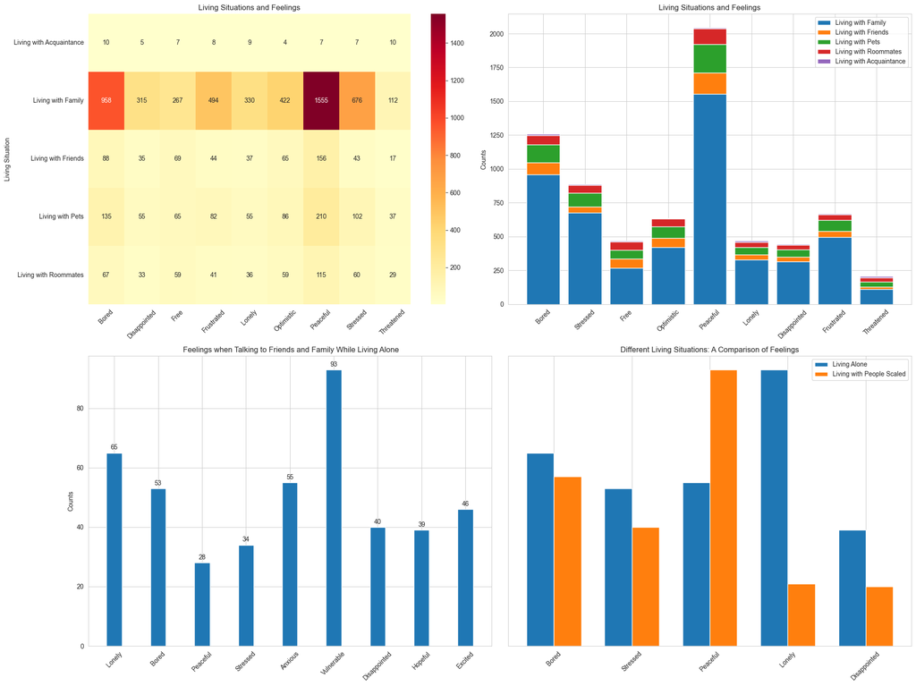

```python
living = ['Live_with_Family', 'Live_with_Friends', 'Live_with_Pets', 'Live_with_Roommates',
          'Live_with_Acquaintance']

feelDuring = ['Feel_During_Bored', 'Feel_During_Stressed', 'Feel_During_Free',
              'Feel_During_Optimistic', 'Feel_During_Peaceful', 'Feel_During_Lonely',
              'Feel_During_Disappointed', 'Feel_During_Frustrated',
              'Feel_During_Threatened']
living_Alone = ['Live_Alone']
feel_talking = ['Talk_Bored', 'Talk_Stressed', 'Talk_Excited', 'Talk_Hopeful', 'Talk_Peaceful',
                'Talk_Lonely', 'Talk_Vulnerable', 'Talk_Disappointed', 'Talk_Anxious']

living_situations = []
feelings = []
counts = []
response = {}
# Iterate over the DataFrame
for i in range(len(covidclean)):
    for living_condition in living:
        for feeling_condition in feelDuring:
            key = f"{living_condition}_{feeling_condition}"
            # Check if both conditions are "Yes"
            if covidclean[living_condition][i] == "Yes" and covidclean[feeling_condition][i] == "Yes":
                response[key] = response.get(key, 0) + 1
response = {}


for i in range(len(covidclean)):
    for living_condition in living:
        for feeling_condition in feelDuring:
            key = f"{living_condition}_{feeling_condition}"

            if covidclean[living_condition][i] == "Yes" and covidclean[feeling_condition][i] == "Yes":
                response[key] = response.get(key, 0) + 1


data = []
for key, count in response.items():
    parts = key.split('_')
    # Assume the last part of the split is always the feeling condition
    feeling = parts[-1]
    # And the rest of the parts form the living situation
    living_situation = '_'.join(parts[:-1])
    data.append({'Living Situation': living_situation, 'Feeling': feeling, 'Count': count})

df = pd.DataFrame(data)
pivot_table = df.pivot(index='Living Situation', columns='Feeling', values='Count').fillna(0)


stacked_data = {living_condition: [response.get(f"{living_condition}_{feeling}", 0) for feeling in feelDuring] for living_condition in living}

stacked_values = np.array(list(stacked_data.values()))
response_alone = {}

for i in range(len(covidclean)):
    for living_condition in living_Alone:
        for talking_feeling_condition in feel_talking:
            key = f"{living_condition}_{talking_feeling_condition}"
            if covidclean[living_condition][i] == "Yes" and covidclean[talking_feeling_condition][i] == "Yes":
                response_alone[key] = response_alone.get(key, 0) + 1
response_flipped = {}
response = {}

for i in range(len(covidclean)):
    for living_condition in living:
        for feeling_condition in feelDuring:
            key = f"{living_condition}_{feeling_condition}"
            # Check if both conditions are "Yes"
            if covidclean[living_condition][i] == "Yes" and covidclean[feeling_condition][i] == "Yes":
                if key in response:
                    response[key] += 1
                else:
                    response[key] = 1
for feeling_condition in feelDuring:
    response_flipped[feeling_condition] = sum(response.get(f"{living_condition}_{feeling_condition}", 0)
                                              for living_condition in living)
feelings =['Bored', 'Stressed', 'Peaceful','Lonely', 'Disappointed']

feel_talking_counts = [response_alone.get(f'Live_Alone_{feeling}', 0) for feeling in feel_talking]

values_alone = [response_alone.get(f'Live_Alone_Talk_{feeling}', 0) for feeling in feelings]

values_living = [sum(response.get(f'{condition}_Feel_During_{feeling}', 0) for condition in living)
                 for feeling in feelings]

max_value_alone = max(values_alone)
max_value_living = max(values_living)
scale_factor = max_value_alone / max_value_living if max_value_living != 0 else 1

scaled_values_living = [round(value * scale_factor) for value in values_living]

x1 = np.arange(len(feel_talking))
width1 = 0.35  # the width of the bars

x = np.arange(len(feelings))
width = 0.35
fig, ax = plt.subplots(2, 2, figsize=(20, 15))


pivot_table = df.pivot(index='Living Situation', columns='Feeling', values='Count')

# Create the heatmap
sns.heatmap(data=pivot_table, ax=ax[0, 0], annot=True, fmt="d", cmap='YlOrRd')
ax[0,0].set_xticklabels(['Bored','Disappointed', 'Free','Frustrated','Lonely',
              'Optimistic', 'Peaceful','Stressed',
              'Threatened'], rotation=45)
ax[0,0].set_yticklabels(['Living with Acquaintance', 'Living with Family', 'Living with Friends',
                         'Living with Pets', 'Living with Roommates'])
ax[0,0].set_title('Living Situations and Feelings')
ax[0,0].set_xlabel("", rotation=45)
#plot 2
bottom_values = np.zeros(len(feelDuring))

for i, (living_condition, values) in enumerate(stacked_data.items()):
    ax[0, 1].bar(feelDuring, values, bottom=bottom_values, label=living_condition)
    bottom_values += values

ax[0, 1].set_ylabel('Counts')
ax[0, 1].set_title('Living Situations and Feelings')
ax[0, 1].set_xticks(range(len(feelDuring)))
ax[0, 1].set_xticklabels(['Bored', 'Stressed', 'Free', 'Optimistic', 'Peaceful',
                          'Lonely', 'Disappointed', 'Frustrated', 'Threatened'], rotation=45)

# Adjusting legend labels
legend = ax[0, 1].legend()
legend.texts[0].set_text('Living with Family')
legend.texts[1].set_text('Living with Friends')
legend.texts[2].set_text('Living with Pets')
legend.texts[3].set_text('Living with Roommates')
legend.texts[4].set_text('Living with Acquaintance')
# Plot 3
rects = ax[1,0].bar(x1, feel_talking_counts, width1)
ax[1,0].set_ylabel('Counts')
ax[1,0].set_title(' Feelings when Talking to Friends and Family While Living Alone')
ax[1,0].set_xticks(x1)
ax[1,0].set_xticklabels(['Lonely','Bored','Peaceful','Stressed','Anxious','Vulnerable'
,'Disappointed','Hopeful','Excited'], rotation=45)

for rect in rects:
    height = rect.get_height()
    ax[1,0].annotate('{}'.format(height),
                xy=(rect.get_x() + rect.get_width() / 2, height),
                xytext=(0, 3),
                textcoords="offset points",
                ha='center', va='bottom')
#plot 4
rects1 = ax[1,1].bar(x - width/2, values_alone, width, label='Living Alone')
rects2 = ax[1,1].bar(x + width/2, scaled_values_living, width, label='Combined Living Situations')
ax[1,1].set_title("Different Living Situations: A Comparison of Feelings")
ax[1,1].set_xticks(x)
ax[1,1].set_xticklabels(feelings, rotation=45)
ax[1,1].set_yticks([])
legend = ax[1,1].legend()
legend.texts[0].set_text('Living Alone')
legend.texts[1].set_text('Living with People Scaled')
#ax[1,1].subplots_adjust(hspace=1)

plt.tight_layout()

plt.show()
```

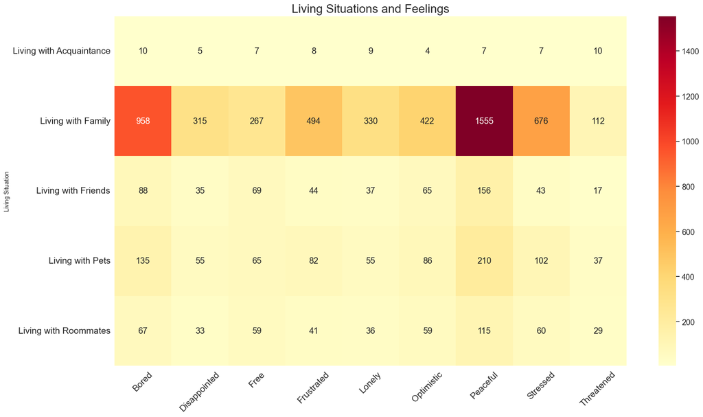

```python
fig, ax = plt.subplots(figsize=(18, 10))
sns.set(font_scale=1.2)
pivot_table = df.pivot(index='Living Situation', columns='Feeling', values='Count')
sns.heatmap(data=pivot_table, annot=True, fmt="d", cmap='YlOrRd')
ax.set_xticklabels(['Bored','Disappointed', 'Free','Frustrated','Lonely',
              'Optimistic', 'Peaceful','Stressed',
              'Threatened'], rotation=45,size=15)
ax.set_yticklabels(['Living with Acquaintance', 'Living with Family', 'Living with Friends',
                         'Living with Pets', 'Living with Roommates'],size=15)
ax.set_title('Living Situations and Feelings')
ax.title.set_size(20)
ax.set_xlabel("", rotation=45)
plt.tight_layout()

plt.show()
```

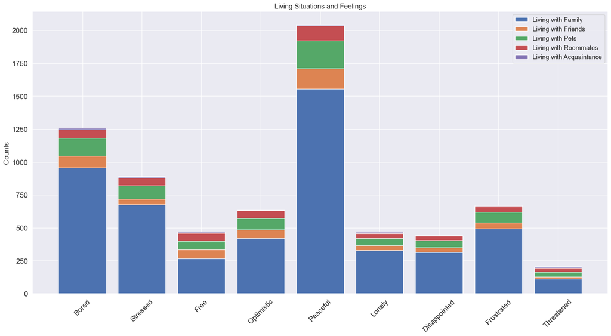

```python
#plot 2
feelDuring = ['Feel_During_Bored', 'Feel_During_Stressed', 'Feel_During_Free',
              'Feel_During_Optimistic', 'Feel_During_Peaceful', 'Feel_During_Lonely',
              'Feel_During_Disappointed', 'Feel_During_Frustrated',
              'Feel_During_Threatened']
fig, ax = plt.subplots(figsize=(18, 10))
sns.set(font_scale=1.2)
bottom_values = np.zeros(len(feelDuring))

for i, (living_condition, values) in enumerate(stacked_data.items()):
    ax.bar(feelDuring, values, bottom=bottom_values, label=living_condition)
    bottom_values += values

ax.set_ylabel('Counts',size=15)
ax.set_title('Living Situations and Feelings')
ax.set_xticks(range(len(feelDuring)))
ax.set_xticklabels(['Bored', 'Stressed', 'Free', 'Optimistic', 'Peaceful',
                          'Lonely', 'Disappointed', 'Frustrated', 'Threatened'], rotation=45,size=15)
plt.yticks(fontsize=15)
# Adjusting legend labels
legend = ax.legend()
legend.texts[0].set_text('Living with Family')
legend.texts[1].set_text('Living with Friends')
legend.texts[2].set_text('Living with Pets')
legend.texts[3].set_text('Living with Roommates')
legend.texts[4].set_text('Living with Acquaintance')

plt.tight_layout()

plt.show()
```

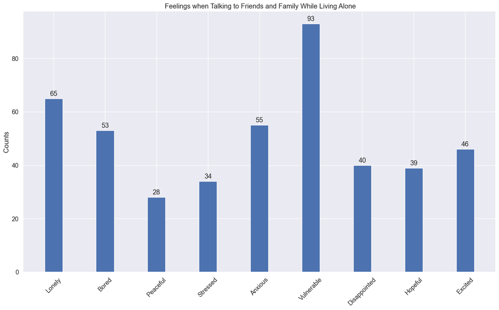

```python
# Plot 3
fig, ax = plt.subplots(figsize=(18, 10))
sns.set(font_scale=1.2)
rects = ax.bar(x1, feel_talking_counts, width1)
ax.set_ylabel('Counts')
ax.set_title(' Feelings when Talking to Friends and Family While Living Alone')
ax.set_xticks(x1)
ax.set_xticklabels(['Lonely','Bored','Peaceful','Stressed','Anxious','Vulnerable'
,'Disappointed','Hopeful','Excited'], rotation=45)

for rect in rects:
    height = rect.get_height()
    ax.annotate('{}'.format(height),
                xy=(rect.get_x() + rect.get_width() / 2, height),
                xytext=(0, 3),
                textcoords="offset points",
                ha='center', va='bottom')
```

```python
print(pivot_table)
result = list(zip(feelDuring, bottom_values))
print(result)
```

```
Feeling                             Bored  Disappointed  Free  Frustrated  \
Living Situation
Live_with_Acquaintance_Feel_During     10             5     7           8
Live_with_Family_Feel_During          958           315   267         494
Live_with_Friends_Feel_During          88            35    69          44
Live_with_Pets_Feel_During            135            55    65          82
Live_with_Roommates_Feel_During        67            33    59          41

Feeling                             Lonely  Optimistic  Peaceful  Stressed  \
Living Situation
Live_with_Acquaintance_Feel_During       9           4         7         7
Live_with_Family_Feel_During           330         422      1555       676
Live_with_Friends_Feel_During           37          65       156        43
Live_with_Pets_Feel_During              55          86       210       102
Live_with_Roommates_Feel_During         36          59       115        60

Feeling                             Threatened
Living Situation
Live_with_Acquaintance_Feel_During          10
Live_with_Family_Feel_During               112
Live_with_Friends_Feel_During               17
Live_with_Pets_Feel_During                  37
Live_with_Roommates_Feel_During             29
[('Feel_During_Bored', np.float64(1258.0)), ('Feel_During_Stressed', np.float64(888.0)), ('Feel_During_Free', np.float64(467.0)), ('Feel_During_Optimistic', np.float64(636.0)), ('Feel_During_Peaceful', np.float64(2043.0)), ('Feel_During_Lonely', np.float64(467.0)), ('Feel_During_Disappointed', np.fl…
```

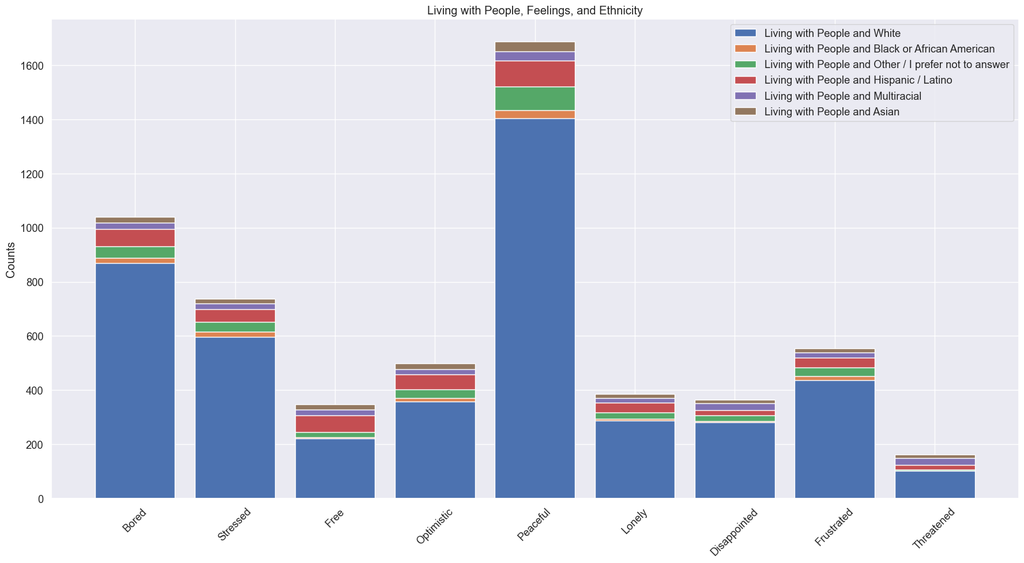

```python
covidclean_b = covidclean.dropna(subset=["Ethnicity"]).reset_index(drop=True)
living = ['Live_with_Family', 'Live_with_Friends', 'Live_with_Pets', 'Live_with_Roommates',
          'Live_with_Acquaintance']
response = {}
for i, row in covidclean_b.iterrows():
    ethnic_group = row['Ethnicity']

    if any(row[living_condition] == "Yes" for living_condition in living):
        combined_living = "Living_with_Others"

        for feeling_condition in feelDuring:
            key = f"{combined_living}_{feeling_condition}_{ethnic_group}"
            if row[feeling_condition] == "Yes":
                response[key] = response.get(key, 0) + 1
stacked_data = {"Living_with_Others": {}}

for ethnic_group in set(covidclean_b['Ethnicity']):
    stacked_data["Living_with_Others"][ethnic_group] = [response.get(f"Living_with_Others_{feeling}_{ethnic_group}", 0)
                                                        for feeling in feelDuring]

fig, ax = plt.subplots(figsize=(18, 10))

bottom_values = np.zeros(len(feelDuring))
for i, (combined_living, ethnic_data) in enumerate(stacked_data.items()):
    for j, (ethnic_group, values) in enumerate(ethnic_data.items()):
        ax.bar(feelDuring, values, bottom=bottom_values, label=f"{combined_living} - {ethnic_group}" if i == 0 else "")
        bottom_values += values

ax.set_ylabel('Counts')
ax.set_title('Living with People, Feelings, and Ethnicity')
ax.set_xticks(range(len(feelDuring)))
ax.set_xticklabels(['Bored','Stressed', 'Free','Optimistic', 'Peaceful','Lonely','Disappointed','Frustrated','Threatened'], rotation=45)
legend = ax.legend()
legend.texts[0].set_text('Living with People and White')
legend.texts[1].set_text('Living with People and Black or African American')
legend.texts[2].set_text('Living with People and Other / I prefer not to answer')
legend.texts[3].set_text('Living with People and Hispanic / Latino')
legend.texts[4].set_text('Living with People and Multiracial')
legend.texts[5].set_text('Living with People and Asian')

plt.tight_layout()
plt.show()
```

## Levels of agreetment about measures COVID-19

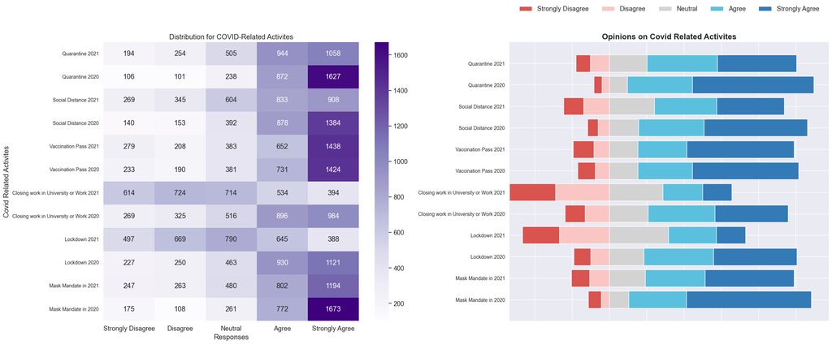

```python
scale_mapping = {
    1: 'Strongly Disagree',
    2: 'Disagree',
    3: 'Neutral',
    4: 'Agree',
    5: 'Strongly Agree'
}

sorted_categories = ['mask20', 'mask21', 'lock20', 'lock21', 'close20', 'close21',
                     'vaccine20', 'vaccine21', 'distance20', 'distance21', 'quarent20', 'quarent21']

df_sorted = covidclean[sorted_categories].applymap(lambda x: scale_mapping.get(x))

response_counts_heatmap = pd.DataFrame(index=sorted_categories, columns=scale_mapping.values())
for column in sorted_categories:
    counts = df_sorted[column].value_counts()
    for response in response_counts_heatmap.columns:
        response_counts_heatmap.at[column, response] = counts.get(response, 0)

response_counts_heatmap = response_counts_heatmap.apply(pd.to_numeric)

response_counts_bar = response_counts_heatmap.copy()
response_counts_heatmap = response_counts_heatmap.iloc[::-1]
fig, ax = plt.subplots(nrows=1, ncols=2, figsize=(24, 10))
sns.set(font_scale=1.2)
sns.heatmap(response_counts_heatmap, annot=True, cmap='Purples', fmt='d', ax=ax[0])
ax[0].set_title('Distribution for COVID-Related Activites')
ax[0].set_xlabel('Responses')
ax[0].set_ylabel('Covid Related Activites')
ax[0].set_yticklabels(["Quarantine 2021","Quarantine 2020","Social Distance 2021","Social Distance 2020"," Vaccination Pass 2021",
                       "Vaccination Pass 2020","Closing work in University or Work 2021",
                       "Closing work in University or Work 2020","Lockdown 2021","Lockdown 2020",
                       "Mask Mandate in 2021","Mask Mandate in 2020"],fontsize=10)

colors = ['#d9534f', '#f9c6c4', '#d3d3d3', '#5bc0de', '#337ab7']
left_starts = -response_counts_bar['Disagree'] - response_counts_bar['Strongly Disagree']
for response, color in zip(response_counts_bar.columns, colors):
    ax[1].barh(response_counts_bar.index, response_counts_bar[response], left=left_starts, color=color, label=response)
    left_starts += response_counts_bar[response]

ax[1].spines['left'].set_visible(False)
ax[1].spines['bottom'].set_visible(False)
ax[1].spines['top'].set_visible(False)
ax[1].spines['right'].set_visible(False)
ax[1].xaxis.set_major_formatter(plt.NullFormatter())
ax[1].legend(loc='upper center', bbox_to_anchor=(0.5, 1.15), ncol=len(response_counts_bar.columns), frameon=False)
ax[1].set_title('Opinions on Covid Related Activites', fontsize=16, fontweight='bold', position=(0.5, 1.1))
ax[1].set_yticks(range(len(sorted_categories)))
ax[1].set_yticklabels(["Mask Mandate in 2020","Mask Mandate in 2021","Lockdown 2020","Lockdown 2021"
                       ,"Closing work in University or Work 2020",
                       "Closing work in University or Work 2021","Vaccination Pass 2020",
                      " Vaccination Pass 2021","Social Distance 2020","Social Distance 2021","Quarantine 2020","Quarantine 2021"], fontsize=10)
plt.tight_layout()
plt.show()
```

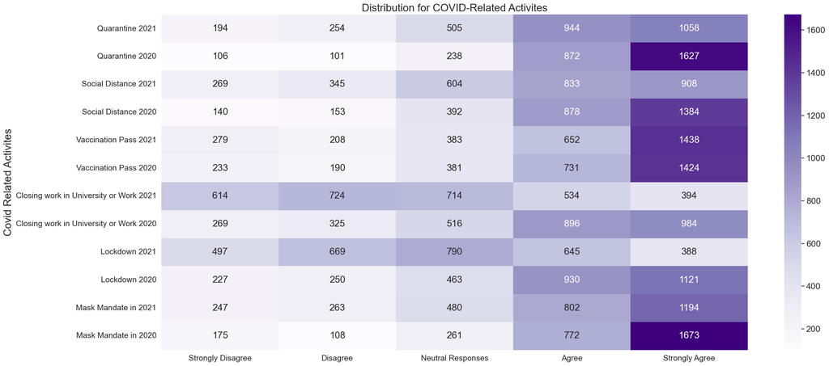

```python
fig, ax = plt.subplots(figsize=(24, 10))
sns.set(font_scale=1.5)
sns.heatmap(response_counts_heatmap, annot=True, cmap='Purples', fmt='d')
ax.set_title('Distribution for COVID-Related Activites',fontsize=20)
ax.set_ylabel('Covid Related Activites',fontsize=20)
ax.set_yticklabels(["Quarantine 2021","Quarantine 2020","Social Distance 2021","Social Distance 2020"," Vaccination Pass 2021",
                       "Vaccination Pass 2020","Closing work in University or Work 2021",
                       "Closing work in University or Work 2020","Lockdown 2021","Lockdown 2020",
                       "Mask Mandate in 2021","Mask Mandate in 2020"],fontsize=15)
ax.set_xticklabels(["Strongly Disagree","Disagree","Neutral Responses","Agree","Strongly Agree"],size=15)
plt.tight_layout()
plt.show()
```

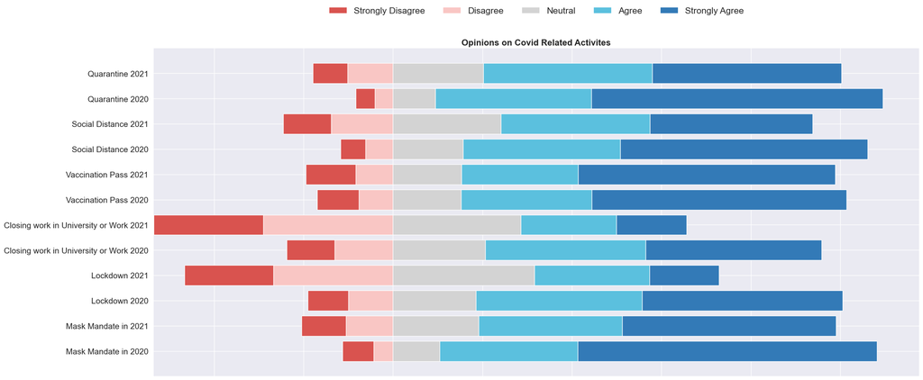

```python
fig, ax = plt.subplots(figsize=(24, 10))
colors = ['#d9534f', '#f9c6c4', '#d3d3d3', '#5bc0de', '#337ab7']
left_starts = -response_counts_bar['Disagree'] - response_counts_bar['Strongly Disagree']
for response, color in zip(response_counts_bar.columns, colors):
    ax.barh(response_counts_bar.index, response_counts_bar[response], left=left_starts, color=color, label=response)
    left_starts += response_counts_bar[response]

ax.spines['left'].set_visible(False)
ax.spines['bottom'].set_visible(False)
ax.spines['top'].set_visible(False)
ax.spines['right'].set_visible(False)
ax.xaxis.set_major_formatter(plt.NullFormatter())
ax.legend(loc='upper center', bbox_to_anchor=(0.5, 1.15), ncol=len(response_counts_bar.columns), frameon=False)
ax.set_title('Opinions on Covid Related Activites', fontsize=16, fontweight='bold', position=(0.5, 1.1))
ax.set_yticks(range(len(sorted_categories)))
ax.set_yticklabels(["Mask Mandate in 2020","Mask Mandate in 2021","Lockdown 2020","Lockdown 2021"
                       ,"Closing work in University or Work 2020",
                       "Closing work in University or Work 2021","Vaccination Pass 2020",
                      " Vaccination Pass 2021","Social Distance 2020","Social Distance 2021","Quarantine 2020","Quarantine 2021"], fontsize=15)
plt.tight_layout()
plt.show()
```

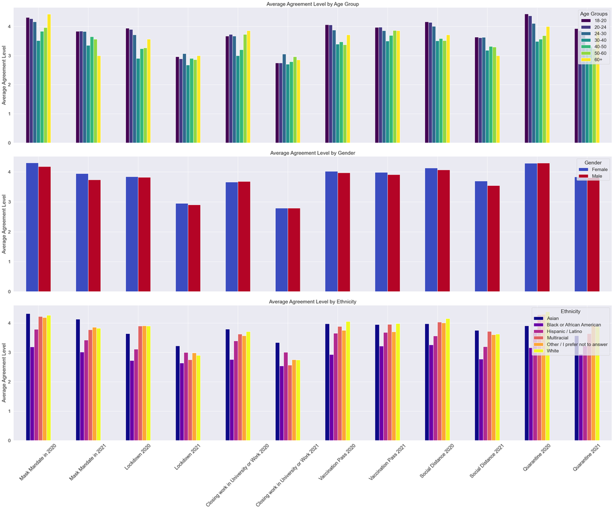

```python
covidclean = covidclean[covidclean['Age'] != 'I prefer not to answer']
covidclean = covidclean[covidclean['Gender'] != 'Not-binary']
covidclean = covidclean[covidclean['Gender'] != 'Other / I prefer not to answer']
def calculate_average_agreement(df, group_col, categories):
    return df.groupby(group_col)[categories].mean()


categories = ['mask20', 'mask21', 'lock20', 'lock21', 'close20', 'close21',
              'vaccine20', 'vaccine21', 'distance20', 'distance21',  'quarent20', 'quarent21']


age_avg = calculate_average_agreement(covidclean, 'Age', categories)
gender_avg = calculate_average_agreement(covidclean, 'Gender', categories)
ethnicity_avg = calculate_average_agreement(covidclean, 'Ethnicity', categories)

age_avg_T = age_avg.T
gender_avg_T = gender_avg.T
ethnicity_avg_T = ethnicity_avg.T

fig, axes = plt.subplots(3, 1, figsize=(30, 25), sharex=True)

# Age group plot
age_avg_T.plot(kind='bar', ax=axes[0], colormap='viridis')
axes[0].set_title('Average Agreement Level by Age Group')
axes[0].set_ylabel('Average Agreement Level')
axes[0].legend(title='Age Groups', loc='upper right')

# Gender plot
gender_avg_T.plot(kind='bar', ax=axes[1], colormap='coolwarm')
axes[1].set_title('Average Agreement Level by Gender')
axes[1].set_ylabel('Average Agreement Level')
axes[1].legend(title='Gender', loc='upper right')

# Ethnicity plot
ethnicity_avg_T.plot(kind='bar', ax=axes[2], colormap='plasma')
axes[2].set_title('Average Agreement Level by Ethnicity')
axes[2].set_ylabel('Average Agreement Level')
axes[2].legend(title='Ethnicity', loc='upper right')
axes[2].set_xticklabels(["Mask Mandate in 2020","Mask Mandate in 2021","Lockdown 2020","Lockdown 2021"
                      ,"Closing work in University or Work 2020",
                     "Closing work in University or Work 2021","Vaccination Pass 2020",
                     " Vaccination Pass 2021","Social Distance 2020","Social Distance 2021","Quarantine 2020","Quarantine 2021"], rotation=45,fontsize=17)

plt.xticks(rotation=45)
plt.tight_layout()
plt.show()
```

## Perception people not vaccine

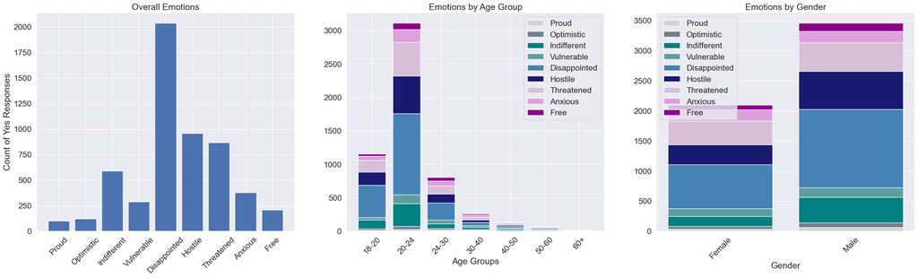

```python
Feeling_NoVac = ['Feel_novacc_Proud', 'Feel_novacc_Optimistic', 'Feel_novacc_Indifferent',
                 'Feel_novacc_Vulnerable', 'Feel_novacc_Disappointed', 'Feel_novacc_Hostile',
                 'Feel_novacc_Threatened', 'Feel_novacc_Anxious', 'Feel_novacc_Free']
feel_labels = ["Proud", "Optimistic", "Indifferent", "Vulnerable",
                 "Disappointed", "Hostile", "Threatened", "Anxious", "Free"]


colors = ["lightgray", "slategray", "teal", "cadetblue", "steelblue", "midnightblue", "thistle", "plum", "darkmagenta"]

age_group_counts = pd.DataFrame()
gender_group_counts = pd.DataFrame()

for feeling in Feeling_NoVac:
    counts_by_age = covidclean.groupby('Age')[feeling].apply(lambda x: (x == 'Yes').sum())
    age_group_counts[feeling] = counts_by_age
    counts_by_gender = covidclean.groupby('Gender')[feeling].apply(lambda x: (x == 'Yes').sum())
    gender_group_counts[feeling] = counts_by_gender

overall_counts = [covidclean[feeling].value_counts().get('Yes', 0) for feeling in Feeling_NoVac]


fig, axes = plt.subplots(nrows=1, ncols=3, figsize=(32, 8))
axes[0].bar(Feeling_NoVac, overall_counts)
axes[0].set_ylabel('Count of Yes Responses')
axes[0].set_title('Overall Emotions')
axes[0].tick_params(axis='x', rotation=45)
axes[0].set_xticks(range(len(["Proud","Optimistic","Indifferent","Vulnerable","Disappointed","Hostile","Threatened","Anxious","Free"])))
axes[0].set_xticklabels(["Proud","Optimistic","Indifferent","Vulnerable","Disappointed","Hostile","Threatened","Anxious","Free"], rotation=45)

bottom_value_age = pd.Series([0]*len(age_group_counts), index=age_group_counts.index)
for i, feeling in enumerate(Feeling_NoVac):
    axes[1].bar(age_group_counts.index, age_group_counts[feeling], bottom=bottom_value_age, color=colors[i], label=feeling)
    bottom_value_age += age_group_counts[feeling]

axes[1].set_xlabel('Age Groups')
axes[1].set_title('Emotions by Age Group')
axes[1].tick_params(axis='x', rotation=45)
legend = axes[1].legend()
for i, feeling in enumerate(Feeling_NoVac):
    if i < len(legend.texts):
        legend.texts[i].set_text(feel_labels[i])

bottom_value_gender = pd.Series([0]*len(gender_group_counts), index=gender_group_counts.index)
for i, feeling in enumerate(Feeling_NoVac):
    axes[2].bar(gender_group_counts.index, gender_group_counts[feeling], bottom=bottom_value_gender, color=colors[i], label=feeling)
    bottom_value_gender += gender_group_counts[feeling]

axes[2].set_xlabel('Gender')
axes[2].set_title('Emotions by Gender')
axes[2].tick_params(axis='x', rotation=45)
legend = axes[2].legend()
for i, feeling in enumerate(Feeling_NoVac):
    if i < len(legend.texts):
        legend.texts[i].set_text(feel_labels[i])

# Convert the DataFrame to a list of tuples (feeling, female_count, male_count)
gender_counts_list = [(feeling,
                       gender_group_counts.loc['Female', feeling],
                       gender_group_counts.loc['Male', feeling])
                      for feeling in Feeling_NoVac]

#print(gender_counts_list)

age_counts_list = [(age_group,
                    age_group_counts.loc[age_group].to_dict())
                   for age_group in age_group_counts.index]

#print(age_counts_list)
```

[output not shown]

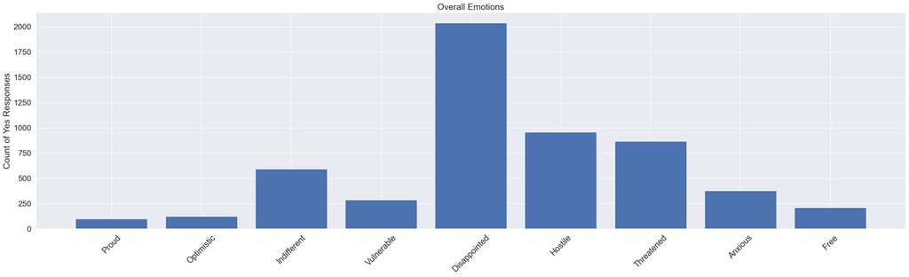

```python
Feeling_NoVac = ['Feel_novacc_Proud', 'Feel_novacc_Optimistic', 'Feel_novacc_Indifferent',
                 'Feel_novacc_Vulnerable', 'Feel_novacc_Disappointed', 'Feel_novacc_Hostile',
                 'Feel_novacc_Threatened', 'Feel_novacc_Anxious', 'Feel_novacc_Free']
feel_labels = ["Proud", "Optimistic", "Indifferent", "Vulnerable",
                 "Disappointed", "Hostile", "Threatened", "Anxious", "Free"]


colors = ["lightgray", "slategray", "teal", "cadetblue", "steelblue", "midnightblue", "thistle", "plum", "darkmagenta"]

age_group_counts = pd.DataFrame()
gender_group_counts = pd.DataFrame()

for feeling in Feeling_NoVac:
    counts_by_age = covidclean.groupby('Age')[feeling].apply(lambda x: (x == 'Yes').sum())
    age_group_counts[feeling] = counts_by_age
    counts_by_gender = covidclean.groupby('Gender')[feeling].apply(lambda x: (x == 'Yes').sum())
    gender_group_counts[feeling] = counts_by_gender

overall_counts = [covidclean[feeling].value_counts().get('Yes', 0) for feeling in Feeling_NoVac]


fig, ax = plt.subplots(figsize=(32, 8))
ax.bar(Feeling_NoVac, overall_counts)
ax.set_ylabel('Count of Yes Responses')
ax.set_title('Overall Emotions')
ax.tick_params(axis='x', rotation=45)
ax.set_xticks(range(len(["Proud","Optimistic","Indifferent","Vulnerable","Disappointed","Hostile","Threatened","Anxious","Free"])))
ax.set_xticklabels(["Proud","Optimistic","Indifferent","Vulnerable","Disappointed","Hostile","Threatened","Anxious","Free"], rotation=45,size=17)
```

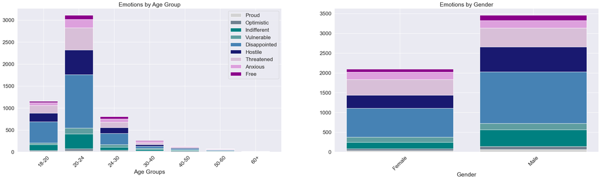

```python
fig, ax = plt.subplots(nrows=1,ncols=2,figsize=(32, 8))
bottom_value_age = pd.Series([0]*len(age_group_counts), index=age_group_counts.index)
for i, feeling in enumerate(Feeling_NoVac):
    ax[0].bar(age_group_counts.index, age_group_counts[feeling], bottom=bottom_value_age, color=colors[i], label=feeling)
    bottom_value_age += age_group_counts[feeling]

ax[0].set_xlabel('Age Groups')
ax[0].set_title('Emotions by Age Group')
ax[0].tick_params(axis='x', rotation=45)
legend = ax[0].legend()
for i, feeling in enumerate(Feeling_NoVac):
    if i < len(legend.texts):
        legend.texts[i].set_text(feel_labels[i])

bottom_value_gender = pd.Series([0]*len(gender_group_counts), index=gender_group_counts.index)
for i, feeling in enumerate(Feeling_NoVac):
    ax[1].bar(gender_group_counts.index, gender_group_counts[feeling], bottom=bottom_value_gender, color=colors[i], label=feeling)
    bottom_value_gender += gender_group_counts[feeling]

ax[1].set_xlabel('Gender')
ax[1].set_title('Emotions by Gender')
ax[1].tick_params(axis='x', rotation=45)
legend = axes[2].legend()
for i, feeling in enumerate(Feeling_NoVac):
    if i < len(legend.texts):
        legend.texts[i].set_text(feel_labels[i])
```

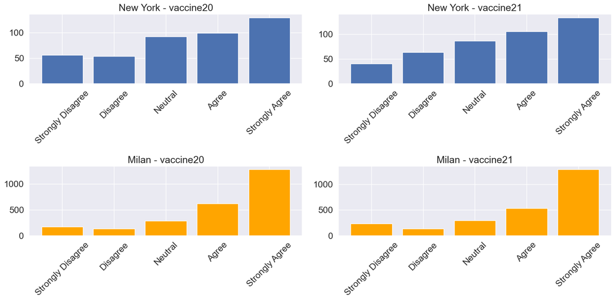

```python
scale_mapping = {
    1: 'Strongly Disagree',
    2: 'Disagree',
    3: 'Neutral',
    4: 'Agree',
    5: 'Strongly Agree'
}

categories = ['vaccine20', 'vaccine21']
df_mapped = covidclean[categories].applymap(lambda x: scale_mapping.get(x, x))

df_milan = df_mapped[covidclean['City'] == "Milan"]
df_new_york = df_mapped[covidclean['City'] == "New York"]

counts_milan = df_milan.apply(pd.Series.value_counts).fillna(0).astype(int)
counts_new_york = df_new_york.apply(pd.Series.value_counts).fillna(0).astype(int)

fig, axes = plt.subplots(nrows=2, ncols=2, figsize=(16, 8), sharey=False)
# Loop through each category and create subplots
for j, category in enumerate(categories):
    # Reindex to ensure all response categories are present
    counts_milan_category = counts_milan[category].reindex(scale_mapping.values(), fill_value=0)
    counts_new_york_category = counts_new_york[category].reindex(scale_mapping.values(), fill_value=0)

    # Plot for New York
    axes[0, j].bar(counts_new_york_category.index, counts_new_york_category.values)
    axes[0, j].set_title(f'New York - {category}')
    axes[0, j].set_xticklabels(counts_new_york_category.index, rotation=45)
    axes[0, j].tick_params(axis='y')  # Allow automatic y-axis ticks

    # Plot for Milan
    axes[1, j].bar(counts_milan_category.index, counts_milan_category.values, color="orange")
    axes[1, j].set_title(f'Milan - {category}')
    axes[1, j].set_xticklabels(counts_milan_category.index, rotation=45)
    axes[1, j].tick_params(axis='y')  # Allow automatic y-axis ticks

# Adjust layout
plt.tight_layout()
plt.show()


# Adjust layout
plt.tight_layout()
plt.show()
```

## Perception upon testing positive

### Positive Test Results by Study Work status

```python
count_positive = ['positive20', 'positive21', 'positive22']
count_yes_positive = covidclean[count_positive].eq('Yes').sum()

# Calculate the total count of positive cases
total_positive = count_yes_positive.sum()

# Calculate the percentages
percentages = (count_yes_positive / total_positive) * 100

# Create a table
test_positive = pd.DataFrame({
    'Total count positive': count_yes_positive,
    'In % of total': percentages.round(2)
})

test_positive
```

|  | Total count positive | In % of total |
| --- | --- | --- |
| positive20 | 371 | 22.84 |
| positive21 | 443 | 27.28 |
| positive22 | 810 | 49.88 |

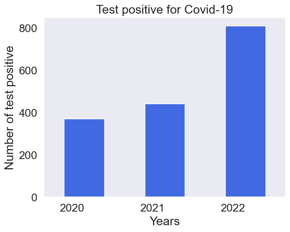

```python
count_positive = ['positive20','positive21','positive22']

count_yes_positive = covidclean[count_positive].eq('Yes').sum()

# Create a table
test_positive = pd.DataFrame({'Count of "Yes" to positive': count_yes_positive})

#Plot
test_positive.index = ['2020', '2021', '2022']
ax = test_positive.plot(kind='bar', color='royalblue')
ax.set_xticklabels(ax.get_xticklabels(), rotation=0, ha='right')

plt.xlabel('Years')
plt.ylabel('Number of test positive')
plt.title('Test positive for Covid-19')
plt.grid(False)
ax.get_legend().remove()
plt.show()
```

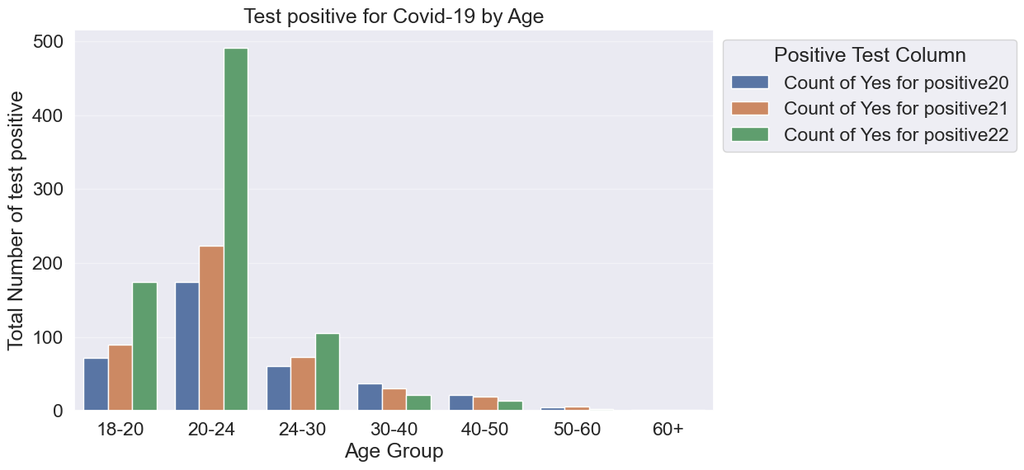

```python
# Convert the 'Age' column to a categorical type with the proper order
age_order = ['18-20', '20-24', '24-30', '30-40', '40-50', '50-60', '60+']
covidclean['Age'] = pd.Categorical(covidclean['Age'], categories=age_order, ordered=True)

# Filter out the 'I prefer not to answer' entries
cc_filtered = covidclean[(covidclean['Age'] != 'I prefer not to answer')]

# Count the occurrences of "Yes" for each positive test column
count_positive = ['positive20', 'positive21', 'positive22']
count_yes_positive = covidclean[count_positive].eq('Yes').sum()

# Filter the DataFrame for "Female" and "Male" genders
filtered_Age = covidclean[covidclean['Age'].isin(age_order)]

# Group by 'Age' and calculate the sum of "Yes" for each positive test column
count_yes_positive_age = (filtered_Age.groupby('Age')[count_positive]
                             .apply(lambda x: x.eq('Yes').sum()))


# Convert the result to a DataFrame for better visualization
count_yes_df = count_yes_positive_age.reset_index().rename(columns={col: f'Count of Yes for {col}' for col in count_positive})

# Plot using seaborn
plt.figure(figsize=(10, 6))
sns.barplot(x='Age', y='value', hue='variable', data=pd.melt(count_yes_df, id_vars=['Age']))
plt.title('Test positive for Covid-19 by Age')
plt.xlabel('Age Group')
plt.ylabel('Total Number of test positive')
plt.legend(title='Positive Test Column', bbox_to_anchor=(1, 1), loc='upper left')
plt.grid(axis='y', alpha=0.4)
plt.show()
```

```python
work_study_counts = covidclean['Work_Study_Status'].value_counts()

# Create a table
work_study_table = pd.DataFrame({'Count': work_study_counts})
total_count = work_study_table['Count'].sum()

# Calculate the percentage
work_study_table['In % of total'] = (work_study_table['Count'] / total_count) * 100
work_study_table
```

| Work_Study_Status | Count | In % of total |
| --- | --- | --- |
| Study | 2476 | 83.423181 |
| Work | 334 | 11.253369 |
| Both | 136 | 4.582210 |
| Neither | 22 | 0.741240 |

```python
count_positive = ['positive20', 'positive21', 'positive22']

# Count the occurrences of "Yes" for each positive test column
count_yes_positive = covidclean[count_positive].eq('Yes').sum()

# Calculate the total count of positive cases
total_positive = count_yes_positive.sum()

# Count the occurrences of each work and study status
work_study_counts = covidclean['Work_Study_Status'].value_counts()

# Create a table for work and study status counts
work_study_table = pd.DataFrame({'Count': work_study_counts})

# Calculate the total count for all work and study statuses
total_count = work_study_table['Count'].sum()

# Create a new DataFrame to store the counts of "Yes" for each work and study status
work_study_positive_counts = pd.DataFrame(index=work_study_table.index)
work_study_positive_counts

# Iterate through positive test columns and count "Yes" for each work and study status
for column in count_positive:
    # Get the base column name without "_Yes" suffix
    base_column_name = column.replace('_Yes', '')
    # Rename the column with "In %" prefix
    work_study_positive_counts[f'In % {base_column_name}'] = covidclean[covidclean[column] == 'Yes']['Work_Study_Status'].value_counts()

# Replace NaN with 0 for cases where there are no "Yes" for a particular positive test column
work_study_positive_counts = work_study_positive_counts.fillna(0)

# Normalize the counts to percentages
work_study_positive_percentage = (work_study_positive_counts / total_count) * 100
work_study_positive_percentage = work_study_positive_percentage.round(2)
work_study_positive_percentage
```

| Work_Study_Status | In % positive20 | In % positive21 | In % positive22 |
| --- | --- | --- | --- |
| Study | 8.66 | 11.56 | 24.29 |
| Work | 3.20 | 2.70 | 1.72 |
| Both | 0.57 | 0.61 | 1.08 |
| Neither | 0.07 | 0.07 | 0.20 |

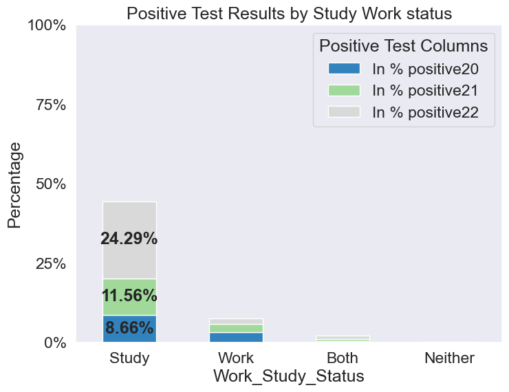

```python
# Plot a stacked bar chart
ax = work_study_positive_percentage.plot(kind='bar', stacked=True, figsize=(8, 6), colormap='tab20c')
plt.title('Positive Test Results by Study Work status')
plt.xlabel('Work_Study_Status')
plt.ylabel('Percentage')
plt.legend(title='Positive Test Columns')

# Add values inside the bar for 'Study' only
for index, row in enumerate(work_study_positive_percentage.iterrows()):
    study_percent20 = row[1]['In % positive20']
    study_percent21 = row[1]['In % positive21']
    study_percent22 = row[1]['In % positive22']

    # Check if the current row corresponds to 'Study'
    if row[0] == 'Study':
        # Display percentage values inside the bar
        ax.text(index, study_percent20 / 2, f'{study_percent20:.2f}%', ha='center', va='center', fontweight='bold')
        ax.text(index, study_percent20 + study_percent21 / 2, f'{study_percent21:.2f}%', ha='center', va='center', fontweight='bold')
        ax.text(index, study_percent20 + study_percent21 + study_percent22 / 2, f'{study_percent22:.2f}%', ha='center', va='center', fontweight='bold')

ax.set_yticks(np.arange(0, 101, 25))
ax.set_yticklabels([f'{y}%' for y in np.arange(0, 101, 25)])
ax.set_xticklabels(work_study_positive_percentage.index, rotation=0)
ax.grid(False)
plt.show()
```

### Positive Test Results by Gender

```python
# Count the occurrences of "Yes" for each positive test column
count_positive = ['positive20', 'positive21', 'positive22']
count_yes_positive = covidclean[count_positive].eq('Yes').sum()

# Filter the DataFrame for "Female" and "Male" genders
filtered_gender = covidclean[covidclean['Gender'].isin(['Female', 'Male'])]

# Group by 'Gender' and calculate the sum of "Yes" for each positive test column
count_yes_positive_gender = (filtered_gender.groupby('Gender')[count_positive]
                             .apply(lambda x: x.eq('Yes').sum()))

# Calculate the total count of positive cases
total_positive = count_yes_positive.sum()

# Create a DataFrame to store the counts by "Gender" and by each positive test column
result_table = pd.DataFrame({
    'For Male': count_yes_positive_gender.loc['Male'],
    'For Female': count_yes_positive_gender.loc['Female']
})

# Calculate the percentages
result_table['Male in % of Total'] = result_table['For Male'] / total_positive * 100
result_table['Female in % of Total'] = result_table['For Female'] / total_positive * 100
result_table
```

|  | For Male | For Female | Male in % of Total | Female in % of Total |
| --- | --- | --- | --- | --- |
| positive20 | 224 | 147 | 13.793103 | 9.051724 |
| positive21 | 278 | 165 | 17.118227 | 10.160099 |
| positive22 | 480 | 330 | 29.556650 | 20.320197 |

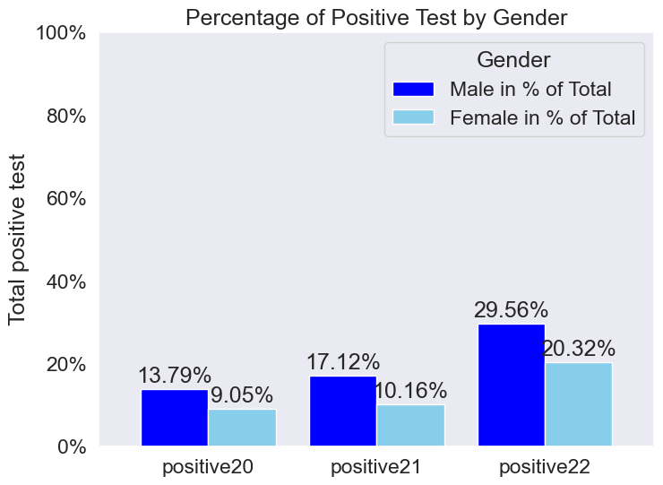

```python
plot_data = result_table[['Male in % of Total', 'Female in % of Total']]

# Set up the bar plot
fig, ax = plt.subplots(figsize=(8, 6))
plot_data.plot(kind='bar', ax=ax, width=0.8, color=['blue', 'skyblue'])
ax.set_xticklabels(count_positive, rotation=0)

# Set plot labels and title
ax.set_ylabel('Total positive test')
ax.set_title('Percentage of Total Positive Cases by Gender and Test')

# Add labels on top of each bar
for p in ax.patches:
    ax.annotate(f'{p.get_height():.2f}%', (p.get_x() + p.get_width() / 2., p.get_height()),
                ha='center', va='center', xytext=(0, 10), textcoords='offset points')

# Set additional features
ax.set_title('Percentage of Positive Test by Gender')
ax.set_yticks(np.arange(0, 101, 20))
ax.set_yticklabels(['{:.0f}%'.format(x) for x in ax.get_yticks()])
ax.legend(title='Gender', loc='upper right', bbox_to_anchor=(1, 1))
ax.grid(False)
plt.show()
```

### - Overall Test Positive on COVID-19 (once /twice / thrice)

```python
count_positive = ['positive20', 'positive21', 'positive22']

# Count the occurrences of "Yes" for each category
count_once = ((covidclean['positive20'] == 'Yes') |
              (covidclean['positive21'] == 'Yes') |
              (covidclean['positive22'] == 'Yes')).sum()

count_twice = ((covidclean['positive20'] == 'Yes') & (covidclean['positive21'] == 'Yes') |
               (covidclean['positive20'] == 'Yes') & (covidclean['positive22'] == 'Yes') |
               (covidclean['positive21'] == 'Yes') & (covidclean['positive22'] == 'Yes')).sum()

count_thrice = ((covidclean['positive20'] == 'Yes') &
                (covidclean['positive21'] == 'Yes') &
                (covidclean['positive22'] == 'Yes')).sum()

# Calculate total count of positive cases
total_positive = count_once + count_twice + count_thrice

# Create a table
test_positive = pd.DataFrame({
    'Counts': [total_positive, count_once, count_twice, count_thrice],
    'In %': [100, count_once / total_positive * 100, count_twice / total_positive * 100, count_thrice / total_positive * 100]
}, index=['Total count of positive', 'Positive Once', 'Positive Twice', 'Positive Thrice'])

test_positive['In %'] = test_positive['In %'].round(2)
test_positive
```

|  | Counts | In % |
| --- | --- | --- |
| Total count of positive | 1624 | 100.00 |
| Positive Once | 1411 | 86.88 |
| Positive Twice | 167 | 10.28 |
| Positive Thrice | 46 | 2.83 |

```python
#Feelings experienced upon testing positive of COVID-19
feel_sick = ['Feel_sick_Stressed', 'Feel_sick_Optimistic', 'Feel_sick_Peace', 'Feel_sick_Lonely', 'Feel_sick_Vulnerable',
             'Feel_sick_Disappointed', 'Feel_sick_Frustrated', 'Feel_sick_Anxious', 'Feel_sick_Threatened']

# Select rows where the test result is positive
positive_rows = covidclean[(covidclean['positive20'] == 'Yes') | (covidclean['positive21'] == 'Yes') | (covidclean['positive22'] == 'Yes')]

# Count the occurrences of "Yes" for each feeling category among positive cases
feel_sick_count_positive = positive_rows[feel_sick].eq('Yes').sum()

# Normalize data
feel_sick_percentage_positive = (feel_sick_count_positive / total_positive) * 100

# Create a table
feel_sick_analysis = pd.DataFrame({
    'Counts': feel_sick_count_positive,
    'In %': feel_sick_percentage_positive.round(2)         # Round to 2 decimal places
}, index=feel_sick)

feel_sick_analysis_sorted = feel_sick_analysis.sort_values(by='In %', ascending=False)
feel_sick_analysis_sorted
```

|  | Counts | In % |
| --- | --- | --- |
| Feel_sick_Peace | 546 | 33.62 |
| Feel_sick_Frustrated | 465 | 28.63 |
| Feel_sick_Lonely | 420 | 25.86 |
| Feel_sick_Stressed | 386 | 23.77 |
| Feel_sick_Vulnerable | 264 | 16.26 |
| Feel_sick_Anxious | 236 | 14.53 |
| Feel_sick_Threatened | 191 | 11.76 |
| Feel_sick_Optimistic | 187 | 11.51 |
| Feel_sick_Disappointed | 125 | 7.70 |

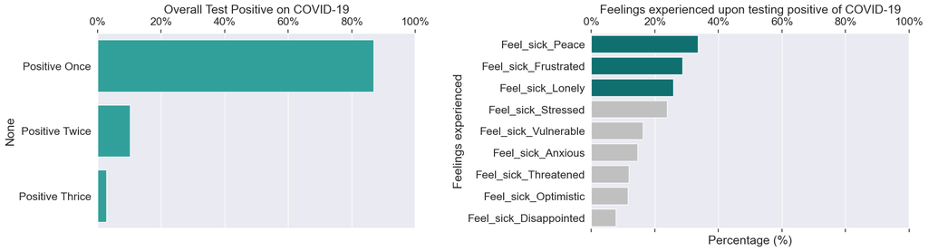

```python
# Create a new figure with two subplots side by side
fig, axs = plt.subplots(1, 2, figsize=(20, 6))

# Plotting on the first subplot (Overall Test Positive on COVID-19)
in_percentage_sorted = test_positive['In %'].drop('Total count of positive').sort_values(ascending=False)
sns.barplot(x=in_percentage_sorted.values, y=in_percentage_sorted.index, palette=['lightseagreen'], ax=axs[0])

axs[0].xaxis.tick_top()
axs[0].set_xticks(np.arange(0, 101, 20))
axs[0].set_xticklabels([f'{x}%' for x in np.arange(0, 101, 20)])
axs[0].set_title('Overall Test Positive on COVID-19')

## Plotting on the second subplot (Feelings experienced upon testing positive)
feel_sick_analysis_sorted = feel_sick_analysis.sort_values(by='In %', ascending=False)

# Visualization of the sorted data
sns.barplot(x='In %', y=feel_sick_analysis_sorted.index, data=feel_sick_analysis_sorted,
            palette=['teal' if i < 3 else 'silver' for i in range(len(feel_sick_analysis_sorted))],
            order=feel_sick_analysis_sorted.index, ax=axs[1])

# % on top
axs[1].xaxis.tick_top()
axs[1].set_xticks(np.arange(0, 101, 20))
axs[1].set_xticklabels([f'{x}%' for x in np.arange(0, 101, 20)])

# % on bottom
axs[1].tick_params(axis='x', which='both', bottom=True, top=True)
axs[1].set_xticks(np.arange(0, 101, 20))
axs[1].set_xticklabels([f'{x}%' for x in np.arange(0, 101, 20)])

axs[1].set_xlabel('Percentage (%)')
axs[1].set_ylabel('Feelings experienced')
axs[1].set_title('Feelings experienced upon testing positive of COVID-19', pad=30)

# Adjust layout
plt.tight_layout(pad=2.0)
plt.show()
```

## Assess feelings about studying during the pandemic, for students.

```python
#from column "Work_Study_Status"
work_study_counts = covidclean['Work_Study_Status'].value_counts()
work_study_counts
```

```
Work_Study_Status
Study      2476
Work        334
Both        136
Neither      22
Name: count, dtype: int64
```

```python
# Filter the DataFrame to include only "Study" and "Both" values in the 'Work_Study_Status' column
student = covidclean[covidclean['Work_Study_Status'].isin(['Study', 'Both'])]

# Count the occurrences of "Study" and "Both"
student_counts = student['Work_Study_Status'].value_counts()
student_counts
```

```
Work_Study_Status
Study    2476
Both      136
Name: count, dtype: int64
```

```python
count_study = ['Feel_study_Bored', 'Feel_study_Stressed', 'Feel_study_Free', 'Feel_study_Proud', 'Feel_study_Optimistic',
               'Feel_study_Lonely', 'Feel_study_Disappointed', 'Feel_study_Frustrated', 'Feel_study_Anxious']

count_study_feel = covidclean[count_study].eq('Yes').sum()

# Create a table
study_feel = pd.DataFrame({'Count': count_study_feel})
study_feel = study_feel.sort_values(by='Count', ascending=False)

# Calculate the percentage and round to 2 decimal places
total_count = study_feel['Count'].sum()
study_feel['In % of total'] = (study_feel['Count'] / total_count) * 100
study_feel['In % of total'] = study_feel['In % of total'].round(2)
study_feel
```

|  | Count | In % of total |
| --- | --- | --- |
| Feel_study_Stressed | 1250 | 20.27 |
| Feel_study_Frustrated | 1004 | 16.28 |
| Feel_study_Bored | 953 | 15.46 |
| Feel_study_Lonely | 941 | 15.26 |
| Feel_study_Anxious | 721 | 11.69 |
| Feel_study_Disappointed | 461 | 7.48 |
| Feel_study_Optimistic | 363 | 5.89 |
| Feel_study_Free | 336 | 5.45 |
| Feel_study_Proud | 137 | 2.22 |

```python
#Checking on the individuals who selected more than one feeling

covidclean['Total_Selected'] = covidclean[count_study].eq('Yes').sum(axis=1)

more_than_one_feel_count = (covidclean['Total_Selected'] > 1).sum()
more_than_one_feel_count
```

```
np.int64(2069)
```

```python
# Remove the 'Total_Selected' column if you don't need it
covidclean.drop('Total_Selected', axis=1, inplace=True)
```

```python
# Define positive and negative feelings
positive_feelings = ['Feel_study_Optimistic', 'Feel_study_Free', 'Feel_study_Proud']
negative_feelings = ['Feel_study_Stressed', 'Feel_study_Frustrated', 'Feel_study_Bored',
                     'Feel_study_Lonely', 'Feel_study_Anxious', 'Feel_study_Disappointed']

# Create a new column 'Feeling_Category'
#Initially, all rows in the 'Feeling_Category' column are set to 'Neutral' So, 'Neutral' is the default category,
#and it is assigned when neither positive feelings('Positive') nor negative feelings('Negative') are indicated in the respective columns.
covidclean['Feeling_Category'] = 'Neutral'
covidclean.loc[covidclean[positive_feelings].eq('Yes').any(axis=1), 'Feeling_Category'] = 'Positive'
covidclean.loc[covidclean[negative_feelings].eq('Yes').any(axis=1), 'Feeling_Category'] = 'Negative'

# Count the occurrences for each category
feeling_category_counts = covidclean['Feeling_Category'].value_counts()

# Create a table for counts
feeling_category_table = pd.DataFrame({'Count': feeling_category_counts})

# Calculate the percentage and round to 2 decimal places
total_count_category = feeling_category_table['Count'].sum()
feeling_category_table['In % of total'] = (feeling_category_table['Count'] / total_count_category) * 100
feeling_category_table['In % of total'] = feeling_category_table['In % of total'].round(2)

# Display the DataFrame
feeling_category_table
```

| Feeling_Category | Count | In % of total |
| --- | --- | --- |
| Negative | 2308 | 77.76 |
| Neutral | 356 | 11.99 |
| Positive | 304 | 10.24 |

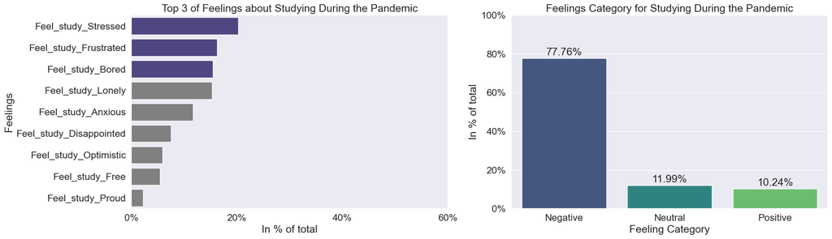

```python
# Create a new figure with two subplots side by side
fig, axs = plt.subplots(1, 2, figsize=(20, 6))

# 1. Plotting on the left subplot
top3_feelings = study_feel.index[:3].tolist()
rest_feelings = study_feel.index[3:].tolist()

# Create a custom color list
custom_colors = ['darkslateblue' if feeling in top3_feelings else 'gray' for feeling in study_feel.index]
sns.barplot(x='In % of total', y=study_feel.index, data=study_feel, palette=custom_colors, ax=axs[0])

# Set x-axis ticks and labels
axs[0].set_xticks(np.arange(0, 61, 20))
axs[0].set_xticklabels([f'{x}%' for x in np.arange(0, 61, 20)])

# Set y-axis label and title
axs[0].set_ylabel('Feelings')
axs[0].set_title('Top 3 of Feelings about Studying During the Pandemic')
axs[0].grid(axis='x')

# 2. Plotting on the right subplot
ax2 = sns.barplot(x=feeling_category_table.index, y='In % of total', data=feeling_category_table, palette='viridis', ax=axs[1])
# axs[1].set_ylabel('Percentage of Total')
axs[1].set_xlabel('Feeling Category')
axs[1].set_title('Feelings Category for Studying During the Pandemic')
axs[1].set_yticks(range(0, 101, 20))
axs[1].set_yticklabels([f'{x}%' for x in np.arange(0, 101, 20)])
axs[1].set_ylim(0, 100)

# Add labels on top of each bar in the right subplot
for p in ax2.patches:
    ax2.annotate(f'{p.get_height():.2f}%', (p.get_x() + p.get_width() / 2., p.get_height()),
                ha='center', va='center', xytext=(0, 10), textcoords='offset points')

# Adjust layout and display the plot
plt.tight_layout()
plt.show()
```

## Examine the emotional responses of professionals in the work environment during COVID-19 and the changes presented in their professional situation.

### Perceptions of professionals in the work environment during COVID-19

```python
count_professional = ['Feel_profess_Free','Feel_profess_Aggressive','Feel_profess_Frustrated','Feel_profess_Disappointed','Feel_profess_Vulnerable',
                       'Feel_profess_Lonely','Feel_profess_Optimistic','Feel_profess_Enthusiastic','Feel_profess_Stressed']

count_profess_feel = covidclean[count_professional].eq('Yes').sum()

# Create a table
profess_feel = pd.DataFrame({'Count': count_profess_feel})
profess_feel = profess_feel.sort_values(by='Count', ascending=False)

total_count_profess = profess_feel['Count'].sum()
profess_feel['In % of total'] = (profess_feel['Count'] / total_count_profess) * 100
profess_feel =  profess_feel.sort_values(by='In % of total', ascending=False)
profess_feel = profess_feel.round(2)
profess_feel
```

|  | Count | In % of total |
| --- | --- | --- |
| Feel_profess_Vulnerable | 109 | 16.49 |
| Feel_profess_Disappointed | 88 | 13.31 |
| Feel_profess_Frustrated | 86 | 13.01 |
| Feel_profess_Optimistic | 74 | 11.20 |
| Feel_profess_Stressed | 65 | 9.83 |
| Feel_profess_Lonely | 64 | 9.68 |
| Feel_profess_Free | 60 | 9.08 |
| Feel_profess_Aggressive | 58 | 8.77 |
| Feel_profess_Enthusiastic | 57 | 8.62 |

```python
#From prof_situation_change column

prof_situation_change = covidclean['prof_situation_change'].value_counts()
prof_situation_change
```

```
prof_situation_change
No, it didn't change                                   97
Yes, I had a reduction in working hours and/or wage    57
Yes, due to smartworking                               45
Yes, my company went out of business                   33
Yes, I quit my job                                     30
Yes, my contract ended                                 30
None of the above                                      18
Yes, I was fired                                       14
Other / I prefer not to answer                         10
Name: count, dtype: int64
```

```python
# Define the categories to be grouped under 'Yes_changed'
grouped_categories = [
    'Yes, I had a reduction in working hours and/or wage',
    'Yes, due to smartworking',
    'Yes, my company went out of business',
    'Yes, I quit my job',
    'Yes, my contract ended',
    'Yes, I was fired'
]

# Create a new column 'prof_situation_grouped'
covidclean['prof_situation_grouped'] = covidclean['prof_situation_change'].replace(grouped_categories, 'Yes_changed')

# Check unique values after replacement
#unique_values_after = covidclean['prof_situation_grouped'].unique()
#print("\nUnique values after replacement:")
#print(unique_values_after)

# Display the updated distribution
prof_situation_change = covidclean['prof_situation_grouped'].value_counts()
print(prof_situation_change)

# Calculate the distribution and percentages
prof_situation_change = covidclean['prof_situation_grouped'].value_counts()
total_count = prof_situation_change.sum()
prof_situation_change_percentage = (prof_situation_change / total_count) * 100
prof_situation_change_percentage.round(2)
```

```
prof_situation_grouped
Yes_changed                       209
No, it didn't change               97
None of the above                  18
Other / I prefer not to answer     10
Name: count, dtype: int64
```

```
prof_situation_grouped
Yes_changed                       62.57
No, it didn't change              29.04
None of the above                  5.39
Other / I prefer not to answer     2.99
Name: count, dtype: float64
```

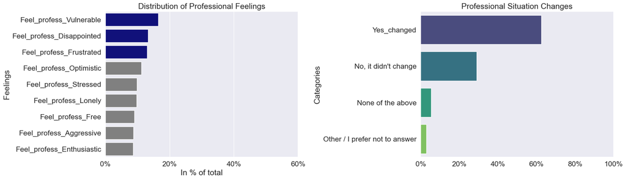

```python
#Subplot of profess_feel and prof_situation_change
plt.figure(figsize=(20, 6))

# First Subplot on the left
plt.subplot(1, 2, 1)
ax1 = sns.barplot(x='In % of total', y=profess_feel.index, data=profess_feel,
                  palette=['darkblue' if val >= profess_feel['In % of total'].nlargest(3).min() else 'gray'
                           for val in profess_feel['In % of total']])
ax1.set_ylabel('Feelings')
ax1.set_title('Distribution of Professional Feelings')
ax1.set_xticks(np.arange(0, 61, 20))
ax1.set_xticklabels([f'{x}%' for x in np.arange(0, 61, 20)])


# 2 Subplot on the right
plt.subplot(1, 2, 2)
ax2 = sns.barplot(x=prof_situation_change_percentage.values, y=prof_situation_change_percentage.index, palette='viridis')
plt.title('Professional Situation Changes')
plt.ylabel('Categories')
ax2.set_xticks(np.arange(0, 101, 20))
ax2.set_xticklabels([f'{x}%' for x in np.arange(0, 101, 20)])
ax2.grid(False)
plt.tight_layout()
plt.show()
```

## Compare comfort levels in social activities between Winter 2021 and Summer 2022.

```python
comfort = ['Comfort_group_21', 'Comfort_go_public_21','Comfort_publictrans_21', 'Comfort_event_outdoor_21',
           'Comfort_group_22', 'Comfort_go_public_22','Comfort_publictrans_22', 'Comfort_event_outdoor_22']

count_comfort = covidclean[comfort].mean().round(2)
count_comfort
```

```
Comfort_group_21            3.83
Comfort_go_public_21        3.26
Comfort_publictrans_21      2.93
Comfort_event_outdoor_21    2.92
Comfort_group_22            4.51
Comfort_go_public_22        4.19
Comfort_publictrans_22      3.74
Comfort_event_outdoor_22    3.90
dtype: float64
```

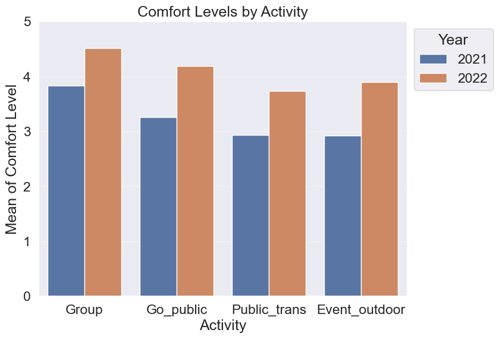

```python
# Define groupings for each year (rank from 1 to 5)

comfort_2021 = ['Comfort_group_21', 'Comfort_go_public_21', 'Comfort_publictrans_21', 'Comfort_event_outdoor_21']
comfort_2022 = ['Comfort_group_22', 'Comfort_go_public_22', 'Comfort_publictrans_22', 'Comfort_event_outdoor_22']

# Create a DataFrame for each year
comfort_2021_data = covidclean[comfort_2021]
comfort_2022_data = covidclean[comfort_2022]

# Calculate the mean comfort level for each activity in 2020 and 2021
mean_comfort_2021 = comfort_2021_data.mean()
mean_comfort_2022 = comfort_2022_data.mean()

# Create a DataFrame for visualization
mean_comfort_comparison_data = pd.DataFrame({
    'Activity': ['Group', 'Go_public', 'Public_trans', 'Event_outdoor'],
    '2021': mean_comfort_2021.values.tolist(),
    '2022': mean_comfort_2022.values.tolist()
})

# Melt the DataFrame for seaborn barplot
melted_data = mean_comfort_comparison_data.melt(id_vars='Activity', var_name='Year', value_name='Mean_Comfort_Level').round(2)

# Extract the activity names without the year suffix
activity_labels = mean_comfort_comparison_data['Activity']

# Plotting side-by-side bar plots
plt.figure(figsize=(8, 6))
sns.barplot(x='Activity', y='Mean_Comfort_Level', hue='Year', data=melted_data)

# Set y-axis limits
plt.ylim(0, 5)
plt.yticks(np.arange(0, 5.9, 1))
plt.title('Comfort Levels by Activity')
#plt.xlabel('Comfort Activity')
plt.ylabel('Mean of Comfort Level')
plt.legend(title='Year', bbox_to_anchor=(1, 1), loc='upper left')
plt.grid(axis='y', alpha=0.4)
plt.show()
```

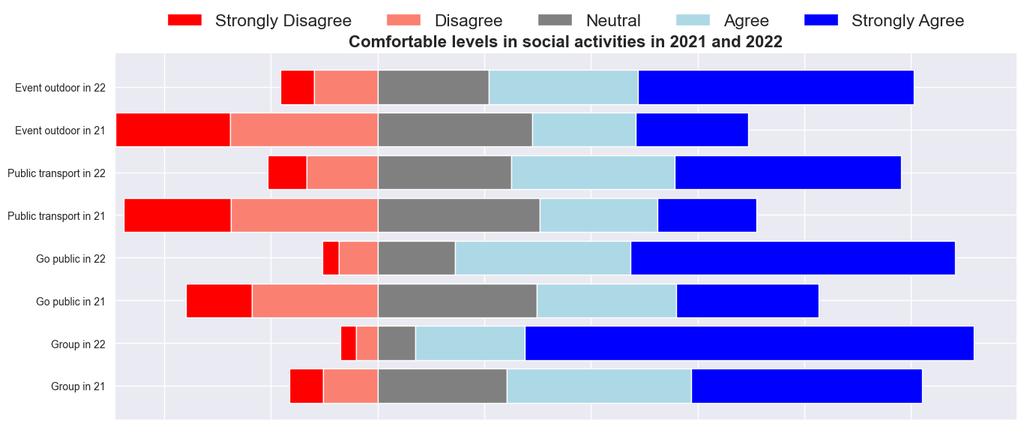

```python
scale_mapping = {
    1: 'Strongly Disagree',
    2: 'Disagree',
    3: 'Neutral',
    4: 'Agree',
    5: 'Strongly Agree'
}

sorted_categories = ['Comfort_group_21', 'Comfort_group_22', 'Comfort_go_public_21', 'Comfort_go_public_22',
                     'Comfort_publictrans_21','Comfort_publictrans_22', 'Comfort_event_outdoor_21', 'Comfort_event_outdoor_22']



df_sorted = covidclean[sorted_categories].applymap(lambda x: scale_mapping.get(x))

response_counts_heatmap = pd.DataFrame(index=sorted_categories, columns=scale_mapping.values())
for column in sorted_categories:
    counts = df_sorted[column].value_counts()
    for response in response_counts_heatmap.columns:
        response_counts_heatmap.at[column, response] = counts.get(response, 0)

response_counts_heatmap = response_counts_heatmap.apply(pd.to_numeric)

response_counts_bar = response_counts_heatmap.copy()



# Assuming ax is defined before this point
fig, ax = plt.subplots(figsize=(14, 6))

# Define new colors
colors = ['red', 'salmon', 'gray', 'lightblue', 'blue']

left_starts = -response_counts_bar['Disagree'] - response_counts_bar['Strongly Disagree']

for response, color in zip(response_counts_bar.columns, colors):
    ax.barh(response_counts_bar.index, response_counts_bar[response], left=left_starts, color=color, label=response)
    left_starts += response_counts_bar[response]

ax.spines['left'].set_visible(False)
ax.spines['bottom'].set_visible(False)
ax.spines['top'].set_visible(False)
ax.spines['right'].set_visible(False)
ax.xaxis.set_major_formatter(plt.NullFormatter())
ax.legend(loc='upper center', bbox_to_anchor=(0.5, 1.15), ncol=len(response_counts_bar.columns), frameon=False)
ax.set_title('Comfortable levels in social activities in 2021 and 2022', fontsize=16, fontweight='bold', position=(0.5, 1.1))
ax.set_yticks(range(len(sorted_categories)))
ax.set_yticklabels(["Group in 21", "Group in 22", "Go public in 21", "Go public in 22", "Public transport in 21",
                    "Public transport in 22", "Event outdoor in 21", "Event outdoor in 22"], fontsize=10)
plt.tight_layout()
plt.show()
```

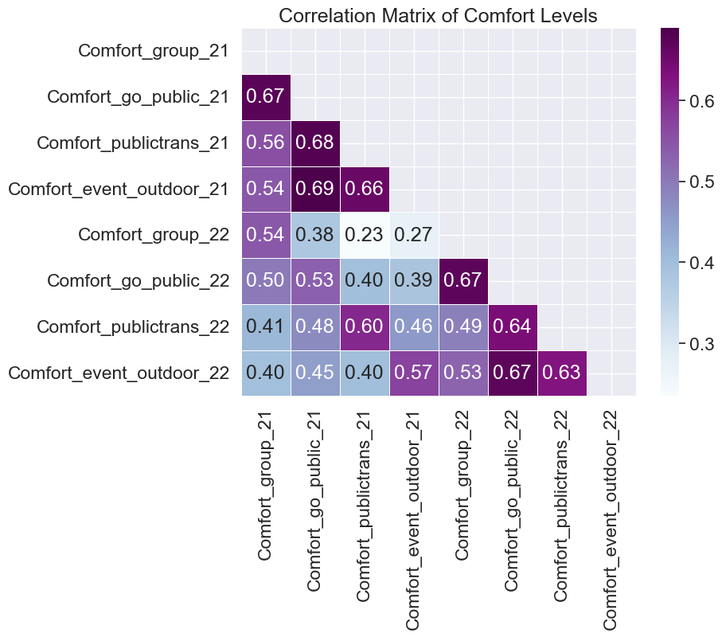

```python
# Select relevant columns for comfort levels
comfort_columns = [
    'Comfort_group_21', 'Comfort_go_public_21',
    'Comfort_publictrans_21', 'Comfort_event_outdoor_21',
    'Comfort_group_22', 'Comfort_go_public_22',
    'Comfort_publictrans_22', 'Comfort_event_outdoor_22'
]

# Extract the relevant data
comfort_data = covidclean[comfort_columns]

# Calculate the correlation matrix
correlation_matrix = comfort_data.corr()

# Generate a mask for the upper triangle
mask = np.triu(np.ones_like(correlation_matrix, dtype=bool))

# Create a heatmap for visualization, only showing the lower triangle
plt.figure(figsize=(8, 6))
sns.heatmap(correlation_matrix, annot=True, cmap='BuPu', fmt=".2f", linewidths=.5, mask=mask)
plt.title('Correlation Matrix of Comfort Levels')
plt.show()
```

## Individual’s perception of returning to one's pre-pandemic self.

```python
covidclean.dropna(subset = ['Feel_normal']).head()
```

|  | City | Work_Study_Status | Live_with_Family | Live_with_Friends | Live_with_Pets | Live_with_Roommates | Live_with_Acquaintance | Live_Alone | Feel_During_Bored | Feel_During_Stressed | ... | Comfort_event_outdoor_22 | Feel_normal | Job_sector | School_major | Gender | Age | Ethnicity | Emotion | Feeling_Category | prof_situation_grouped |
| --- | --- | --- | --- | --- | --- | --- | --- | --- | --- | --- | --- | --- | --- | --- | --- | --- | --- | --- | --- | --- | --- |
| 0 | New York | Study | Yes | No | No | No | No | No | No | No | ... | 2.0 | 4.0 | NaN | Engineering and Technology | Male | 24-30 | Asian | Stressed | Positive | NaN |
| 1 | New York | Both | Yes | No | No | No | No | No | Yes | No | ... | 4.0 | 4.0 | NaN | Engineering and Technology | Female | 24-30 | Asian | Frustrated | Negative | NaN |
| 2 | New York | Work | No | No | No | Yes | No | No | No | Yes | ... | 5.0 | 8.0 | Information Technology | NaN | Male | 30-40 | Asian | Distant | Neutral | No, it didn't change |
| 3 | New York | Work | No | No | Yes | No | No | No | Yes | No | ... | 3.0 | 5.0 | Food & Consumer Goods | NaN | Male | 40-50 | White | Frustrated | Neutral | No, it didn't change |
| 4 | New York | Work | No | No | No | No | No | Yes | No | No | ... | 5.0 | 6.0 | Food & Consumer Goods | NaN | Male | 30-40 | White | Optimistic | Neutral | No, it didn't change |

5 rows × 95 columns

```python
def plot_text(ax, x, text, color):
    """Helper function to plot text on axes."""
    ax.text(x, ax.get_ylim()[0] - (ax.get_ylim()[1] - ax.get_ylim()[0]) * 0.12, text, ha='center', va='top', color=color, fontsize=10)
```

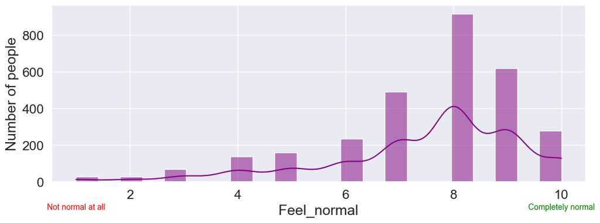

```python
fig, ax = plt.subplots(figsize=(12, 4))

# Plot the histogram on the first subplot
sns.histplot(x="Feel_normal", data=covidclean, binwidth=0.4, color='purple', kde=True)
plot_text(ax ,1, 'Not normal at all', 'red')
plot_text(ax, 10, 'Completely normal', 'green')
ax.set(ylabel="Number of people");
```

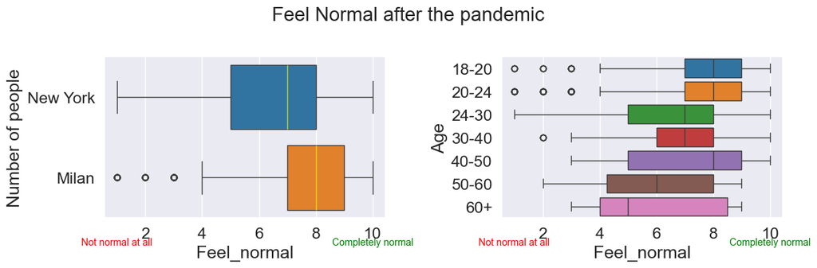

```python
# Convert the 'Age' column to a categorical type with the proper order
age_order = ['18-20', '20-24', '24-30', '30-40', '40-50', '50-60', '60+']
covidclean['Age'] = pd.Categorical(covidclean['Age'], categories=age_order, ordered=True)

# Filter out the 'I prefer not to answer' entries
cc_filtered = covidclean[(covidclean['Age'] != 'I prefer not to answer')]

# Create a figure with 1 row and 2 columns
fig, (ax1, ax2) = plt.subplots(1, 2, figsize=(12,4))

sns.boxplot(data=cc_filtered, x="Feel_normal", y="City", palette='tab10', medianprops=dict(color="yellow", alpha=0.7), ax=ax1)
plot_text(ax1, 1, 'Not normal at all', 'red')
plot_text(ax1, 10, 'Completely normal', 'green')
ax1.set(ylabel="Number of people")

sns.boxplot(data=cc_filtered, x="Feel_normal", y="Age", palette='tab10',ax=ax2)
plot_text(ax2, 1, 'Not normal at all', 'red')
plot_text(ax2, 10, 'Completely normal', 'green')
ax2.set(ylabel="Age")

# Adjust layout and show the plot
fig.suptitle('Feel Normal after the pandemic', fontsize=20)
plt.tight_layout()
plt.show()
```

## Predominant emotion participants associate with COVID-19

```python
general_emotion=cc_filtered.dropna(subset = ['Emotion'])
```

```python
general_emotion.groupby(['Emotion']).size()
```

```
Emotion
Anxious          71
Disappointed     56
Distant          50
Free             40
Frustrated      130
Lonely           52
Optimistic       38
Peaceful         35
Stressed         61
Vulnerable       61
dtype: int64
```

```python
positive_emotions = ['Free', 'Optimistic', 'Peaceful']
negative_emotions = ['Anxious', 'Disappointed', 'Frustrated','Distant','Lonely','Stressed','Vulnerable']

# Function to classify each emotion
def classify_emotion(emotion):
    if emotion in positive_emotions:
        return 'Positive'
    elif emotion in negative_emotions:
        return 'Negative'

general_emotion['Emotion_Type'] = general_emotion['Emotion'].apply(classify_emotion)
```

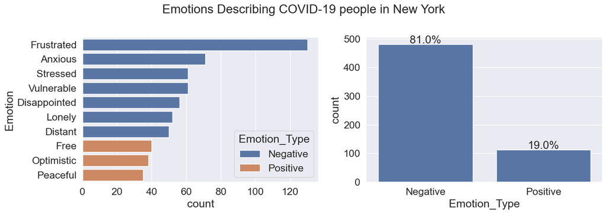

```python
# Create a figure with 1 row and 2 columns
fig, axes = plt.subplots(nrows=1, ncols=2, figsize=(14, 5))

# Plot the countplot on the first subplot
sns.countplot(y="Emotion", hue='Emotion_Type', data=general_emotion, order=general_emotion['Emotion'].value_counts(ascending=False).index, ax=axes[0])

# Plot the countplot on the second subplot
ax2 = sns.countplot(x='Emotion_Type', data=general_emotion, ax=axes[1])

# Calculate total number of entries in the data to find the percentage
total = len(general_emotion['Emotion_Type'])

# Annotate each bar with the percentage
for p in ax2.patches:
    height = p.get_height()  # Height of the bar represents the count
    percentage = 100 * height / total  # Calculate percentage
    # Adding text to each bar
    ax2.text(p.get_x() + p.get_width()/2., height + 3, '{:1.1f}%'.format(percentage), ha="center")


# Adjust layout and show the plot
fig.suptitle('Emotions Describing COVID-19 people in New York', fontsize=20)
plt.tight_layout()
plt.show()
```

```python
general_emotion['Emotion'].value_counts(ascending=False)
```

```
Emotion
Frustrated      130
Anxious          71
Stressed         61
Vulnerable       61
Disappointed     56
Lonely           52
Distant          50
Free             40
Optimistic       38
Peaceful         35
Name: count, dtype: int64
```

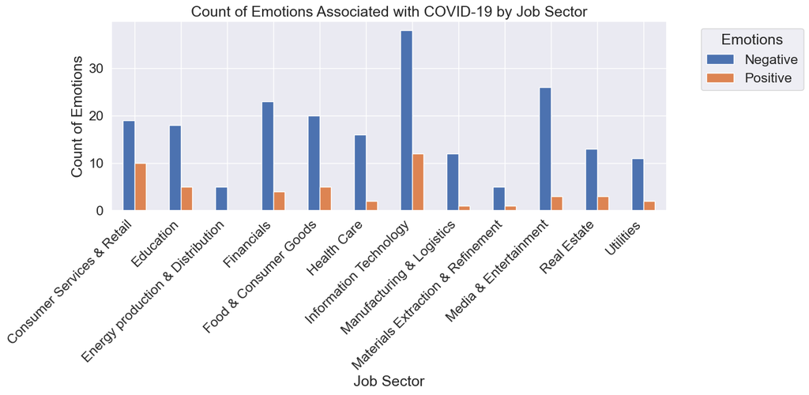

```python
cc_filtered2 = general_emotion[(general_emotion['Job_sector'] != 'Other / I prefer not to answer')]

emotion_counts = pd.crosstab(cc_filtered2['Job_sector'], cc_filtered2['Emotion_Type'])

# Let's plot the grouped bar chart using the crosstab
plt.figure(figsize=(10, 8))
emotion_counts.plot(kind='bar', stacked=False, figsize=(14,7))

plt.title('Count of Emotions Associated with COVID-19 by Job Sector')
plt.xlabel('Job Sector')
plt.ylabel('Count of Emotions')
plt.xticks(rotation=45, ha='right')
plt.legend(title='Emotions', bbox_to_anchor=(1.05, 1), loc='upper left')
plt.tight_layout()

plt.show()
```

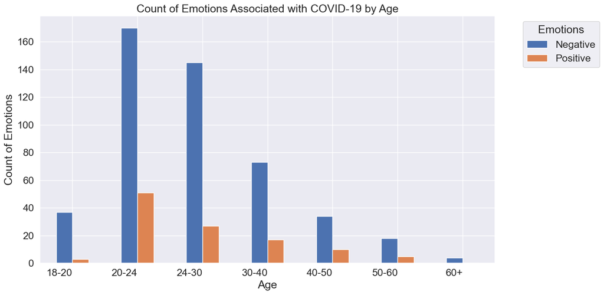

```python
emotion_counts = pd.crosstab(general_emotion['Age'], general_emotion['Emotion_Type'])

# Let's plot the grouped bar chart using the crosstab
plt.figure(figsize=(10, 8))
emotion_counts.plot(kind='bar', stacked=False, figsize=(14,7))

plt.title('Count of Emotions Associated with COVID-19 by Age')
plt.xlabel('Age')
plt.ylabel('Count of Emotions')
plt.xticks(rotation=0, ha='right')
plt.legend(title='Emotions', bbox_to_anchor=(1.05, 1), loc='upper left')
plt.tight_layout();
plt.show();
```

# Cleaning Data Set Tweets

```python
tweets = pd.read_csv('data/covid19_tweets.csv')
tweets
```

|  | user_name | user_location | user_description | user_created | user_followers | user_friends | user_favourites | user_verified | date | text | hashtags | source | is_retweet |
| --- | --- | --- | --- | --- | --- | --- | --- | --- | --- | --- | --- | --- | --- |
| 0 | ᏉᎥ☻լꂅϮ | astroworld | wednesday addams as a disney princess keepin i... | 2017-05-26 05:46:42 | 624 | 950 | 18775 | False | 2020-07-25 12:27:21 | If I smelled the scent of hand sanitizers toda... | NaN | Twitter for iPhone | False |
| 1 | Tom Basile 🇺🇸 | New York, NY | Husband, Father, Columnist & Commentator. Auth... | 2009-04-16 20:06:23 | 2253 | 1677 | 24 | True | 2020-07-25 12:27:17 | Hey @Yankees @YankeesPR and @MLB - wouldn't it... | NaN | Twitter for Android | False |
| 2 | Time4fisticuffs | Pewee Valley, KY | #Christian #Catholic #Conservative #Reagan #Re... | 2009-02-28 18:57:41 | 9275 | 9525 | 7254 | False | 2020-07-25 12:27:14 | @diane3443 @wdunlap @realDonaldTrump Trump nev... | ['COVID19'] | Twitter for Android | False |
| 3 | ethel mertz | Stuck in the Middle | #Browns #Indians #ClevelandProud #[]_[] #Cavs ... | 2019-03-07 01:45:06 | 197 | 987 | 1488 | False | 2020-07-25 12:27:10 | @brookbanktv The one gift #COVID19 has give me... | ['COVID19'] | Twitter for iPhone | False |
| 4 | DIPR-J&K | Jammu and Kashmir | 🖊️Official Twitter handle of Department of Inf... | 2017-02-12 06:45:15 | 101009 | 168 | 101 | False | 2020-07-25 12:27:08 | 25 July : Media Bulletin on Novel #CoronaVirus... | ['CoronaVirusUpdates', 'COVID19'] | Twitter for Android | False |
| ... | ... | ... | ... | ... | ... | ... | ... | ... | ... | ... | ... | ... | ... |
| 179103 | AJIMATI AbdulRahman O. | Ilorin, Nigeria | Animal Scientist\|\| Muslim\|\| Real Madrid/Chelsea | 2013-12-30 18:59:19 | 412 | 1609 | 1062 | False | 2020-08-29 19:44:21 | Thanks @IamOhmai for nominating me for the @WH... | ['WearAMask'] | Twitter for Android | False |
| 179104 | Jason | Ontario | When your cat has more baking soda than Ninja ... | 2011-12-21 04:41:30 | 150 | 182 | 7295 | False | 2020-08-29 19:44:16 | 2020! The year of insanity! Lol! #COVID19 http... | ['COVID19'] | Twitter for Android | False |
| 179105 | BEEHEMOTH ⏳ | 🇨🇦 Canada | ⚒️ The Architects of Free Trade ⚒️ Really Did ... | 2016-07-13 17:21:59 | 1623 | 2160 | 98000 | False | 2020-08-29 19:44:15 | @CTVNews A powerful painting by Juan Lucena. I... | NaN | Twitter Web App | False |
| 179106 | Gary DelPonte | New York City | Global UX UI Visual Designer. StoryTeller, Mus... | 2009-10-27 17:43:13 | 1338 | 1111 | 0 | False | 2020-08-29 19:44:14 | More than 1,200 students test positive for #CO... | ['COVID19'] | Twitter for iPhone | False |
| 179107 | TUKY II | Aliwal North, South Africa | TOKELO SEKHOPA \| TUKY II \| LAST BORN \| EISH TU... | 2018-04-14 17:30:07 | 97 | 1697 | 566 | False | 2020-08-29 19:44:08 | I stop when I see a Stop\n\n@SABCNews\n@Izinda... | NaN | Twitter for Android | False |

179108 rows × 13 columns

```python
tweets1=pd.DataFrame(tweets[['text','user_location']])
tweets1
```

|  | text | user_location |
| --- | --- | --- |
| 0 | If I smelled the scent of hand sanitizers toda... | astroworld |
| 1 | Hey @Yankees @YankeesPR and @MLB - wouldn't it... | New York, NY |
| 2 | @diane3443 @wdunlap @realDonaldTrump Trump nev... | Pewee Valley, KY |
| 3 | @brookbanktv The one gift #COVID19 has give me... | Stuck in the Middle |
| 4 | 25 July : Media Bulletin on Novel #CoronaVirus... | Jammu and Kashmir |
| ... | ... | ... |
| 179103 | Thanks @IamOhmai for nominating me for the @WH... | Ilorin, Nigeria |
| 179104 | 2020! The year of insanity! Lol! #COVID19 http... | Ontario |
| 179105 | @CTVNews A powerful painting by Juan Lucena. I... | 🇨🇦 Canada |
| 179106 | More than 1,200 students test positive for #CO... | New York City |
| 179107 | I stop when I see a Stop\n\n@SABCNews\n@Izinda... | Aliwal North, South Africa |

179108 rows × 2 columns

Code obtain with the sentyment analyst GPT, first install the Texblob

```python
from textblob import TextBlob
import re

# Function to clean the text data
def clean_text(text):
    text = re.sub(r'http\S+', '', text)  # Remove URLs
    text = re.sub(r'@\w+', '', text)  # Remove mentions
    text = re.sub(r'#', '', text)  # Remove hashtags symbol
    text = re.sub(r'RT[\s]+', '', text)  # Remove RT (retweet symbol)
    text = re.sub(r'[^\w\s]', '', text)  # Remove punctuations
    text = text.lower()  # Convert to lower case
    return text

# Filter the dataset for COVID-19 related texts
covid_related_terms = ['covid', 'covid19', 'coronavirus']
tweets1['text_cleaned'] = tweets1['text'].apply(clean_text)
data_covid = tweets1[tweets1['text_cleaned'].str.contains('|'.join(covid_related_terms))]

# Function to analyze sentiment
def analyze_sentiment(text):
    analysis = TextBlob(text)
    return analysis.sentiment.polarity, analysis.sentiment.subjectivity

# Applying sentiment analysis
data_covid['polarity'], data_covid['subjectivity'] = zip(*data_covid['text_cleaned'].apply(analyze_sentiment))

# Classify sentiments as positive, negative, or neutral
data_covid['sentiment'] = data_covid['polarity'].apply(lambda x: 'positive' if x > 0 else ('negative' if x < 0 else 'neutral'))

# Displaying the first few rows of the processed data
data_covid[['text', 'text_cleaned', 'polarity', 'subjectivity', 'sentiment','user_location']].head()
```

|  | text | text_cleaned | polarity | subjectivity | sentiment | user_location |
| --- | --- | --- | --- | --- | --- | --- |
| 2 | @diane3443 @wdunlap @realDonaldTrump Trump nev... | trump never once claimed covid19 was a hoax... | 0.00 | 0.000000 | neutral | Pewee Valley, KY |
| 3 | @brookbanktv The one gift #COVID19 has give me... | the one gift covid19 has give me is an apprec... | 0.00 | 0.357143 | neutral | Stuck in the Middle |
| 4 | 25 July : Media Bulletin on Novel #CoronaVirus... | 25 july media bulletin on novel coronavirusup... | 0.00 | 0.000000 | neutral | Jammu and Kashmir |
| 5 | #coronavirus #covid19 deaths continue to rise.... | coronavirus covid19 deaths continue to rise it... | -0.70 | 0.666667 | negative | Новоро́ссия |
| 6 | How #COVID19 Will Change Work in General (and ... | how covid19 will change work in general and re... | 0.05 | 0.500000 | positive | Gainesville, FL |

```python
pd.set_option('display.max_colwidth', None)
data_covid.head(50)
```

|  | text | user_location | text_cleaned | polarity | subjectivity | sentiment |
| --- | --- | --- | --- | --- | --- | --- |
| 2 | @diane3443 @wdunlap @realDonaldTrump Trump never once claimed #COVID19 was a hoax. We all claim that this effort to… https://t.co/Jkk8vHWHb3 | Pewee Valley, KY | trump never once claimed covid19 was a hoax we all claim that this effort to | 0.000000 | 0.000000 | neutral |
| 3 | @brookbanktv The one gift #COVID19 has give me is an appreciation for the simple things that were always around me… https://t.co/Z0pOAlFXcW | Stuck in the Middle | the one gift covid19 has give me is an appreciation for the simple things that were always around me | 0.000000 | 0.357143 | neutral |
| 4 | 25 July : Media Bulletin on Novel #CoronaVirusUpdates #COVID19 \n@kansalrohit69 @DrSyedSehrish @airnewsalerts @ANI… https://t.co/MN0EEcsJHh | Jammu and Kashmir | 25 july media bulletin on novel coronavirusupdates covid19 \n | 0.000000 | 0.000000 | neutral |
| 5 | #coronavirus #covid19 deaths continue to rise. It's almost as bad as it ever was. Politicians and businesses want… https://t.co/hXMHooXX2C | Новоро́ссия | coronavirus covid19 deaths continue to rise its almost as bad as it ever was politicians and businesses want | -0.700000 | 0.666667 | negative |
| 6 | How #COVID19 Will Change Work in General (and recruiting, specifically) via/ @ProactiveTalent #Recruiting… https://t.co/bjZxzGPMbK | Gainesville, FL | how covid19 will change work in general and recruiting specifically via recruiting | 0.050000 | 0.500000 | positive |
| 8 | Praying for good health and recovery of @ChouhanShivraj .\n#covid19\n#covidPositive | NaN | praying for good health and recovery of \ncovid19\ncovidpositive | 0.700000 | 0.600000 | positive |
| 9 | POPE AS GOD - Prophet Sadhu Sundar Selvaraj. Watch here at https://t.co/7X5RTyKVji \n\n#HurricaneHanna #COVID19… https://t.co/06dZcGUnwL | 👇🏻location at link below👇🏻 | pope as god prophet sadhu sundar selvaraj watch here at \n\nhurricanehanna covid19 | 0.000000 | 0.000000 | neutral |
| 10 | 49K+ Covid19 cases still no response from \n@cbseindia29 @HRDMinistry @DrRPNishank.Please cancel the compartment exa… https://t.co/kV2ZKmumu1 | NaN | 49k covid19 cases still no response from \n please cancel the compartment exa | 0.000000 | 0.000000 | neutral |
| 12 | 👋🏻@PattyHajdu @NavdeepSBains — no one will be safe from #COVID19 until everyone is safe. Will you commit to ensure… https://t.co/aWCJo6eKvC | Hotel living - various cities! Who needs a home when hotel living is so fabulous! | no one will be safe from covid19 until everyone is safe will you commit to ensure | 0.500000 | 0.500000 | positive |
| 13 | Let's all protect ourselves from #COVID19.\nIt's real and the numbers are climbing up fast in the Continent.\nLet's n… https://t.co/byMSfxltrw | Africa | lets all protect ourselves from covid19\nits real and the numbers are climbing up fast in the continent\nlets n | 0.200000 | 0.450000 | positive |
| 14 | Rajasthan Government today started a Plasma Bank at Sawai Man Singh Hospital in Jaipur for treatment of COVID-19 pa… https://t.co/cwfCcWyaDA | New Delhi | rajasthan government today started a plasma bank at sawai man singh hospital in jaipur for treatment of covid19 pa | 0.000000 | 0.000000 | neutral |
| 15 | Nagaland police on Covid-19 Awareness at City Tower Junction Dimapur.\n\n#Covid19 #keepsocialdistance… https://t.co/WOvFMqhuEO | Nagaland, India | nagaland police on covid19 awareness at city tower junction dimapur\n\ncovid19 keepsocialdistance | 0.000000 | 0.000000 | neutral |
| 16 | July 25 #COVID19 update\n#TamilNadu - 6988\nDischarge- 7758\nPeople tested - 61729\nActice cases - 52273\n#chennai - 1329 | NaN | july 25 covid19 update\ntamilnadu 6988\ndischarge 7758\npeople tested 61729\nactice cases 52273\nchennai 1329 | 0.000000 | 0.000000 | neutral |
| 17 | Second wave of #COVID19 in Flanders..back to more #homework again... https://t.co/9swImZACMN | Brussels | second wave of covid19 in flandersback to more homework again | 0.250000 | 0.250000 | positive |
| 19 | COVID Update: The infection rate in Florida is following the natural curve that experts predicted if the initial cu… https://t.co/hmEwE747WK | Florida, USA | covid update the infection rate in florida is following the natural curve that experts predicted if the initial cu | 0.033333 | 0.166667 | positive |
| 21 | Coronavirus - South Africa: COVID-19 update for South Africa (24 July 2020) @nicd_sa @MoetiTshidi @WHOAFRO… https://t.co/WQzAdkpXC5 | #AFRICA #MENA | coronavirus south africa covid19 update for south africa 24 july 2020 | 0.000000 | 0.000000 | neutral |
| 23 | The first comprehensive review of #WASH &amp; #COVID19.\n\nAnalysis: key ways in which WASH can help reduce transmission… https://t.co/eCsfDmo9b4 | 100+ countries | the first comprehensive review of wash amp covid19\n\nanalysis key ways in which wash can help reduce transmission | 0.125000 | 0.666667 | positive |
| 24 | Holy water in times of #COVID19 https://t.co/YaZ49yxL27 | Graz | holy water in times of covid19 | 0.000000 | 0.000000 | neutral |
| 25 | #Kolar\nNeed #Blood Type : B-positive\nAt : Jalappa Hospital\nBlood Component : Need Plasma from B+ve #COVID19 recove… https://t.co/XtgxULc02Z | Mumbai, India | kolar\nneed blood type bpositive\nat jalappa hospital\nblood component need plasma from bve covid19 recove | 0.000000 | 0.000000 | neutral |
| 27 | I can imagine the same people profiting off the human suffering of #COVID19 will be studying these maps to make 207… https://t.co/NElsmGju2H | Manhattan, NY | i can imagine the same people profiting off the human suffering of covid19 will be studying these maps to make 207 | 0.000000 | 0.112500 | neutral |
| 28 | #TNCoronaUpdate\n\n#TN crosses 2 lakh mark and 1,50,055 ppp has recovered so far.\n\n#COVID19 positive today 6988/total… https://t.co/QdJkpcc7qv | no e-pass to cross borders... | tncoronaupdate\n\ntn crosses 2 lakh mark and 150055 ppp has recovered so far\n\ncovid19 positive today 6988total | 0.163636 | 0.772727 | positive |
| 30 | #FEMA acknowledges #PuertoRico lacks rebuilt homes and a hospital to survive #COVID19 https://t.co/PLXqKc5K5d | United States | fema acknowledges puertorico lacks rebuilt homes and a hospital to survive covid19 | 0.000000 | 0.000000 | neutral |
| 31 | Actor @VishalKOfficial and his father Mr.G.K.Reddy tested positive for #Covid19 15/20 days back..\n\nWhile #Vishal 's… https://t.co/V5Lo8NRLWY | Chennai, India | actor and his father mrgkreddy tested positive for covid19 1520 days back\n\nwhile vishal s | 0.113636 | 0.272727 | positive |
| 32 | An update on the total #covid19 cases, recoveries, and deaths reported in countries in #Africa. See the total numb… https://t.co/eqCJ3EhwRi | Miami, FL | an update on the total covid19 cases recoveries and deaths reported in countries in africa see the total numb | -0.200000 | 0.833333 | negative |
| 33 | @unionwill @megawedgy @jjhorgan “Regarding the community outbreak of #COVID19 on Haida Gwaii: 13 cases (one recover… https://t.co/rJzuY60qY7 | British Columbia, Canada | regarding the community outbreak of covid19 on haida gwaii 13 cases one recover | 0.000000 | 0.000000 | neutral |
| 35 | Our CEO @RamneekHH live with @SASCO_Jikelele WSU talking about, “The effects of Covid-19 on students”.… https://t.co/VMN2LxHAds | South Africa | our ceo live with wsu talking about the effects of covid19 on students | 0.136364 | 0.500000 | positive |
| 36 | @NicoleKowalski5 @chrisdameanor19 I'm feeling a little anxious because #COVID19 seems to have detracted everyone's… https://t.co/A3mHdXamLg | Deep Heart Texas | im feeling a little anxious because covid19 seems to have detracted everyones | -0.218750 | 0.750000 | negative |
| 37 | Actionables for a healthy recovery from #COVID19 #climate https://t.co/crGlKZOz5Z | NaN | actionables for a healthy recovery from covid19 climate | 0.500000 | 0.500000 | positive |
| 39 | We released two new #COVID19 podcast episodes this week:\n-Technology Platforms Used to Conduct Telehealth Visits\n-C… https://t.co/G94VeYVCzk | Bethesda, Maryland | we released two new covid19 podcast episodes this week\ntechnology platforms used to conduct telehealth visits\nc | 0.136364 | 0.454545 | positive |
| 40 | #PlayYourPart in the fight against #COVID19 . Each one of us can make a difference in containing the spread, lets… https://t.co/fRzLgrS8Qf | Cavan, Ireland | playyourpart in the fight against covid19 each one of us can make a difference in containing the spread lets | 0.000000 | 0.000000 | neutral |
| 41 | Britain didn't understand #Covid19 for months, while plenty of other countries did understand it and took effective… https://t.co/KV2CAQ6skZ | A UK I no longer recognise | britain didnt understand covid19 for months while plenty of other countries did understand it and took effective | 0.237500 | 0.587500 | positive |
| 42 | Volume for those at the back please. 🔊 #COVID19 https://t.co/d0pn2Bv2Hx | Port Elizabeth, South Africa | volume for those at the back please covid19 | 0.000000 | 0.000000 | neutral |
| 43 | #Delhi reports 1,142 #COVID19 positive cases and 29 deaths on Saturday. Death toll rises to 3,806, reports ANI quot… https://t.co/JxsVpWMRQS | New Delhi, India | delhi reports 1142 covid19 positive cases and 29 deaths on saturday death toll rises to 3806 reports ani quot | 0.227273 | 0.545455 | positive |
| 45 | #TamilNadu \| #COVID19 \| 25th July\n\n● TN - 6,988 (Highest Spike)\n\n● Total Cases - 2,06,737\n\n● Chennai - 1,329… https://t.co/X8zgUzC0Gr | chennai | tamilnadu covid19 25th july\n\n tn 6988 highest spike\n\n total cases 206737\n\n chennai 1329 | 0.000000 | 0.750000 | neutral |
| 46 | Why has Ruto not eulogisied Mkapa!! \nAsking for Moses Kuria \n\nRaila \n#RutoSwindlingGEMA \n#COVID19 | Nairobi | why has ruto not eulogisied mkapa \nasking for moses kuria \n\nraila \nrutoswindlinggema \ncovid19 | 0.000000 | 0.000000 | neutral |
| 47 | Coronavirus Testing Fiasco: St Mirren have pledged to undertake an "urgent review" of their Covid-19 testing proced… https://t.co/0MCEUERQ74 | worldwide | coronavirus testing fiasco st mirren have pledged to undertake an urgent review of their covid19 testing proced | 0.000000 | 0.000000 | neutral |
| 48 | Coronavirus Testing Fiasco: St Mirren have pledged to undertake an "urgent review" of their Covid-19 testing proced… https://t.co/AkxvIaD1Pr | Scotland | coronavirus testing fiasco st mirren have pledged to undertake an urgent review of their covid19 testing proced | 0.000000 | 0.000000 | neutral |
| 49 | #TamilNadu \| #COVID19 \| 25th July\n● TN - 6,988 (Highest Spike)\n● Total Cases - 2,06,737\n● Chennai - 1,329\n● T… https://t.co/ZWFKJwZdEo | NaN | tamilnadu covid19 25th july\n tn 6988 highest spike\n total cases 206737\n chennai 1329\n t | 0.000000 | 0.750000 | neutral |
| 50 | Coronavirus Testing Fiasco: St Mirren have pledged to undertake an "urgent review" of their Covid-19 testing proced… https://t.co/Ifse0whbVE | Australia | coronavirus testing fiasco st mirren have pledged to undertake an urgent review of their covid19 testing proced | 0.000000 | 0.000000 | neutral |
| 51 | Coronavirus Testing Fiasco: St Mirren have pledged to undertake an "urgent review" of their Covid-19 testing proced… https://t.co/dx8Yt7CvsM | UK | coronavirus testing fiasco st mirren have pledged to undertake an urgent review of their covid19 testing proced | 0.000000 | 0.000000 | neutral |
| 52 | Coronavirus Testing Fiasco: St Mirren have pledged to undertake an "urgent review" of their Covid-19 testing proced… https://t.co/h7p44XIzuk | San Francisco | coronavirus testing fiasco st mirren have pledged to undertake an urgent review of their covid19 testing proced | 0.000000 | 0.000000 | neutral |
| 54 | Coronavirus Testing Fiasco: St Mirren have pledged to undertake an "urgent review" of their Covid-19 testing proced… https://t.co/bfel6gyXIq | USA | coronavirus testing fiasco st mirren have pledged to undertake an urgent review of their covid19 testing proced | 0.000000 | 0.000000 | neutral |
| 55 | Coronavirus Testing Fiasco: St Mirren have pledged to undertake an "urgent review" of their Covid-19 testing proced… https://t.co/eu5g2djZYx | Baton Rouge, USA | coronavirus testing fiasco st mirren have pledged to undertake an urgent review of their covid19 testing proced | 0.000000 | 0.000000 | neutral |
| 56 | .@nytimes reporting that yesterday 1145 people died of #COVID19 in the USA. Over 73K new cases were reported. Serio… https://t.co/sFwP0v7FEB | Queens, NY | reporting that yesterday 1145 people died of covid19 in the usa over 73k new cases were reported serio | 0.136364 | 0.454545 | positive |
| 57 | Crazy that the world has come to this but as Americans we will fight to get through this!🇺🇸🇺🇸🇺🇸🇺🇸🇺🇸 #covid19 | New Orleans, LA | crazy that the world has come to this but as americans we will fight to get through this covid19 | -0.600000 | 0.900000 | negative |
| 58 | @jimsciutto @JoAnnBaldwin55 People whose relatives have died from #COVID19 should file a class action lawsuit against Sinclair Broadcasting. | NaN | people whose relatives have died from covid19 should file a class action lawsuit against sinclair broadcasting | 0.100000 | 0.100000 | positive |
| 59 | US #CoronaVirus: 4,249,584 cases and 148,521 deaths reported in the United States to date.\n\n1,257 new cases and 31… https://t.co/j4TreMnKW5 | NaN | us coronavirus 4249584 cases and 148521 deaths reported in the united states to date\n\n1257 new cases and 31 | 0.136364 | 0.454545 | positive |
| 61 | I miss isopropyl alcohol so much!!!! Ethanol in hand sanitizer smells like I poured tequila on my hands 🤢 #COVID19 | astroworld | i miss isopropyl alcohol so much ethanol in hand sanitizer smells like i poured tequila on my hands covid19 | 0.200000 | 0.200000 | positive |
| 63 | @SonuSood sir mom is in ICU due to COVID just want prayers from you and everyone who is listening you . #COVID19 | NaN | sir mom is in icu due to covid just want prayers from you and everyone who is listening you covid19 | -0.125000 | 0.375000 | negative |
| 64 | Due to #COVID19 aka #Coronavirus Ill be sending the first 500 people to like &amp; retweet this $300 -$1500 through Cas… https://t.co/3MkuUsGBDk | Marietta, GA | due to covid19 aka coronavirus ill be sending the first 500 people to like amp retweet this 300 1500 through cas | -0.125000 | 0.569444 | negative |

```python
data_covid.info()
```

```
<class 'pandas.core.frame.DataFrame'>
Index: 113141 entries, 2 to 179106
Data columns (total 6 columns):
 #   Column         Non-Null Count   Dtype
---  ------         --------------   -----
 0   text           113141 non-null  object
 1   user_location  90423 non-null   object
 2   text_cleaned   113141 non-null  object
 3   polarity       113141 non-null  float64
 4   subjectivity   113141 non-null  float64
 5   sentiment      113141 non-null  object
dtypes: float64(2), object(4)
memory usage: 6.0+ MB
```

```python
data_covid.groupby('sentiment')['sentiment'].value_counts()
```

```
sentiment
negative    18566
neutral     47800
positive    46775
Name: count, dtype: int64
```

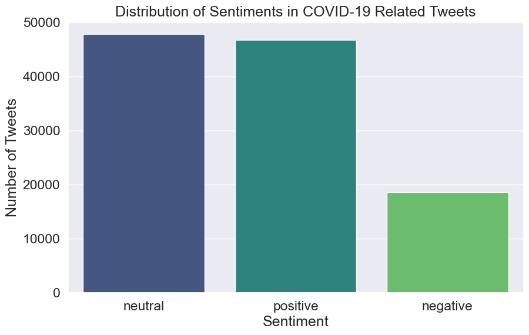

```python
# Counting the number of each sentiment
sentiment_counts = data_covid['sentiment'].value_counts()

# Creating the bar plot
plt.figure(figsize=(10, 6))
sns.barplot(x=sentiment_counts.index, y=sentiment_counts.values, palette="viridis")
plt.title('Distribution of Sentiments in COVID-19 Related Tweets')
plt.xlabel('Sentiment')
plt.ylabel('Number of Tweets')
plt.show()
```

### Checking for country and city Milan and New York in the tweets data set

```python
data_covid['user_location'] = data_covid['user_location'].str.lower()
filtered_counts = data_covid[data_covid['user_location'] == 'milan, italy']['sentiment'].value_counts()
filtered_counts
```

```
sentiment
positive    4
neutral     3
Name: count, dtype: int64
```

```python
from textblob import Blobber
from textblob.sentiments import NaiveBayesAnalyzer
import nltk
nltk.download('movie_reviews')
nltk.download('punkt')


# Initializing TextBlob with NaiveBayesAnalyzer
tb = Blobber(analyzer=NaiveBayesAnalyzer())

# List of specific emotions for categorization
emotions = ['Free', 'Optimistic', 'Peaceful', 'Anxious', 'Disappointed', 'Frustrated', 'Distant', 'Lonely', 'Stressed', 'Vulnerable']

# Function to categorize text into specific emotions
# Note: This is a basic implementation. More complex NLP techniques might be needed for accurate categorization.
def categorize_emotions(text):
    analysis = tb(text)
    categorized_emotions = []

    # Basic keyword matching for emotions
    for emotion in emotions:
        if emotion.lower() in text:
            categorized_emotions.append(emotion)

    # If no specific emotion is found, classify based on sentiment
    if not categorized_emotions:
        if analysis.sentiment.classification == 'pos':
            return ['Optimistic']
        elif analysis.sentiment.classification == 'neg':
            return ['Anxious']
        else:
            return ['Neutral']

    return categorized_emotions

# Applying the emotion categorization function to the dataset
data_covid['emotions'] = data_covid['text_cleaned'].apply(categorize_emotions)

# Displaying the first few rows of the dataset with categorized emotions
data_covid[['text', 'emotions']].head()
```

|  | text | emotions |
| --- | --- | --- |
| 2 | @diane3443 @wdunlap @realDonaldTrump Trump never once claimed #COVID19 was a hoax. We all claim that this effort to… https://t.co/Jkk8vHWHb3 | [Optimistic] |
| 3 | @brookbanktv The one gift #COVID19 has give me is an appreciation for the simple things that were always around me… https://t.co/Z0pOAlFXcW | [Optimistic] |
| 4 | 25 July : Media Bulletin on Novel #CoronaVirusUpdates #COVID19 \n@kansalrohit69 @DrSyedSehrish @airnewsalerts @ANI… https://t.co/MN0EEcsJHh | [Optimistic] |
| 5 | #coronavirus #covid19 deaths continue to rise. It's almost as bad as it ever was. Politicians and businesses want… https://t.co/hXMHooXX2C | [Optimistic] |
| 6 | How #COVID19 Will Change Work in General (and recruiting, specifically) via/ @ProactiveTalent #Recruiting… https://t.co/bjZxzGPMbK | [Optimistic] |

dowloading python -m textblob.download_corpora

```python
data_covid.emotions.value_counts()
```

```
emotions
[Optimistic]             76894
[Anxious]                34787
[Free]                    1112
[Vulnerable]               193
[Stressed]                  42
[Peaceful]                  36
[Disappointed]              25
[Distant]                   18
[Lonely]                    14
[Frustrated]                11
[Free, Peaceful]             4
[Free, Stressed]             1
[Lonely, Stressed]           1
[Anxious, Frustrated]        1
[Anxious, Stressed]          1
[Free, Lonely]               1
Name: count, dtype: int64
```

Another aproach

```python
from nltk.corpus import wordnet as wn
import nltk

# Download necessary NLTK data
nltk.download('wordnet')

# Function to get synonyms and related words for each emotion
def get_related_words(word):
    synonyms = set()
    for synset in wn.synsets(word):
        for lemma in synset.lemmas():
            synonyms.add(lemma.name())  # Add the synonyms
            if lemma.antonyms():  # Optionally, add antonyms
                synonyms.add(lemma.antonyms()[0].name())
    return synonyms

# Extending the list of emotions with their synonyms and related words
extended_emotions = {}
for emotion in emotions:
    extended_emotions[emotion] = get_related_words(emotion.lower())

# Function for emotion categorization with extended emotion words
def advanced_emotion_categorization(text):
    found_emotions = []
    for emotion, related_words in extended_emotions.items():
        if any(word in text for word in related_words):
            found_emotions.append(emotion)
    return found_emotions if found_emotions else ['None']

# Applying the advanced emotion categorization function to the dataset
data_covid['advanced_emotions'] = data_covid['text_cleaned'].apply(advanced_emotion_categorization)

# Displaying the first few rows of the dataset with advanced categorized emotions
data_covid[['text', 'advanced_emotions']].head()
```

|  | text | advanced_emotions |
| --- | --- | --- |
| 2 | @diane3443 @wdunlap @realDonaldTrump Trump never once claimed #COVID19 was a hoax. We all claim that this effort to… https://t.co/Jkk8vHWHb3 | [None] |
| 3 | @brookbanktv The one gift #COVID19 has give me is an appreciation for the simple things that were always around me… https://t.co/Z0pOAlFXcW | [None] |
| 4 | 25 July : Media Bulletin on Novel #CoronaVirusUpdates #COVID19 \n@kansalrohit69 @DrSyedSehrish @airnewsalerts @ANI… https://t.co/MN0EEcsJHh | [None] |
| 5 | #coronavirus #covid19 deaths continue to rise. It's almost as bad as it ever was. Politicians and businesses want… https://t.co/hXMHooXX2C | [None] |
| 6 | How #COVID19 Will Change Work in General (and recruiting, specifically) via/ @ProactiveTalent #Recruiting… https://t.co/bjZxzGPMbK | [None] |

```python
data_covid.advanced_emotions.value_counts()
```

```
advanced_emotions
[None]                                  100337
[Free]                                    4432
[Stressed]                                3128
[Frustrated]                              2371
[Distant]                                 1249
[Anxious]                                  457
[Lonely]                                   217
[Frustrated, Stressed]                     196
[Vulnerable]                               179
[Free, Stressed]                           113
[Free, Frustrated]                          84
[Disappointed, Frustrated]                  71
[Optimistic]                                50
[Peaceful]                                  36
[Free, Distant]                             35
[Distant, Stressed]                         30
[Disappointed]                              17
[Free, Anxious]                             17
[Frustrated, Distant]                       17
[Lonely, Stressed]                          15
[Anxious, Stressed]                         12
[Free, Lonely]                              10
[Anxious, Frustrated]                        9
[Free, Frustrated, Stressed]                 7
[Free, Peaceful]                             7
[Frustrated, Vulnerable]                     4
[Frustrated, Lonely]                         4
[Free, Vulnerable]                           4
[Stressed, Vulnerable]                       3
[Free, Distant, Stressed]                    3
[Anxious, Distant]                           3
[Free, Disappointed, Frustrated]             3
[Optimistic, Peaceful]                       2
[Anxious, Vulnerable]                        2
[Anxious, Lonely]                            2
[Frustrated, Distant, Stressed]              1
[Free, Optimistic, Frustrated]               1
[Anxious, Disappointed, Frustrated]          1
[Optimistic, Stressed]                       1
[Disappointed, Frustrated, Distant]          1
[Peaceful, Frustrated]                       1
[Free, Disappointed]                         1
[Disappointed, Frustrated, Stressed]         1
[Peaceful, Stressed]                         1
[Disappointed, Frustrated, Lonely]           1
[Optimistic, Frustrated]                     1
[Lonely, Vulnerable]                         1
[Free, Frustrated, Distant]                  1
[Free, Anxious, Lonely]                      1
[Anxious, Frustrated, Lonely]                1
Name: count, dtype: int64
```

Approach with out other dataset

```python
# Manually defining common variations for each emotion
emotion_variations = {
    'Free': ['free', 'freedom', 'freely'],
    'Optimistic': ['optimistic', 'optimism', 'optimistically'],
    'Peaceful': ['peaceful', 'peace', 'peacefully'],
    'Anxious': ['anxious', 'anxiety', 'anxiously'],
    'Disappointed': ['disappointed', 'disappointing', 'disappointment'],
    'Frustrated': ['frustrated', 'frustration', 'frustratingly'],
    'Distant': ['distant', 'distance', 'distantly'],
    'Lonely': ['lonely', 'loneliness', 'lone'],
    'Stressed': ['stressed', 'stress', 'stressing'],
    'Vulnerable': ['vulnerable', 'vulnerability', 'vulnerably']
}

# Function for simple emotion categorization based on defined variations
def simple_variation_emotion_categorization(text):
    found_emotions = []
    for emotion, variations in emotion_variations.items():
        if any(variation in text for variation in variations):
            found_emotions.append(emotion)
    return found_emotions if found_emotions else ['None']

# Applying the function to the dataset
data_covid['variation_emotions'] = data_covid['text_cleaned'].apply(simple_variation_emotion_categorization)

# Displaying the first few rows of the dataset with categorized emotions
data_covid[['text', 'variation_emotions']].head()
```

|  | text | variation_emotions |
| --- | --- | --- |
| 2 | @diane3443 @wdunlap @realDonaldTrump Trump never once claimed #COVID19 was a hoax. We all claim that this effort to… https://t.co/Jkk8vHWHb3 | [None] |
| 3 | @brookbanktv The one gift #COVID19 has give me is an appreciation for the simple things that were always around me… https://t.co/Z0pOAlFXcW | [None] |
| 4 | 25 July : Media Bulletin on Novel #CoronaVirusUpdates #COVID19 \n@kansalrohit69 @DrSyedSehrish @airnewsalerts @ANI… https://t.co/MN0EEcsJHh | [None] |
| 5 | #coronavirus #covid19 deaths continue to rise. It's almost as bad as it ever was. Politicians and businesses want… https://t.co/hXMHooXX2C | [None] |
| 6 | How #COVID19 Will Change Work in General (and recruiting, specifically) via/ @ProactiveTalent #Recruiting… https://t.co/bjZxzGPMbK | [None] |

```python
data_covid.variation_emotions.value_counts()
```

```
variation_emotions
[None]                             110530
[Free]                               1093
[Distant]                             314
[Stressed]                            268
[Lonely]                              236
[Vulnerable]                          207
[Peaceful]                            154
[Anxious]                             146
[Optimistic]                           69
[Disappointed]                         40
[Anxious, Stressed]                    25
[Frustrated]                           18
[Free, Stressed]                        7
[Free, Anxious]                         6
[Free, Peaceful]                        6
[Lonely, Stressed]                      5
[Free, Lonely]                          3
[Anxious, Frustrated]                   2
[Free, Distant]                         2
[Distant, Stressed]                     2
[Anxious, Stressed, Vulnerable]         1
[Free, Optimistic]                      1
[Frustrated, Stressed]                  1
[Peaceful, Stressed]                    1
[Frustrated, Lonely]                    1
[Lonely, Vulnerable]                    1
[Distant, Vulnerable]                   1
[Anxious, Lonely]                       1
Name: count, dtype: int64
```

```python
# Extracting the count data from the provided images

general_ny = {
    'Frustrated' : 130,
    'Anxious' : 71,
    'Stressed' : 61,
    'Vulnerable' : 61,
    'Disappointed' : 56,
    'Lonely' : 52,
    'Distant' : 50,
    'Free' : 40,
    'Optimistic' : 38,
    'Peaceful' : 35
}

advanced_emotion_data = {
    'Optimistic': 76894,
    'Anxious': 34787,
    'Free': 1112,
    'Vulnerable': 193,
    'Stressed': 42,
    'Peaceful': 36,
    'Disappointed': 25,
    'Distant': 18,
    'Lonely': 14,
    'Frustrated': 11
}

variation_emotion_data = {
    'None': 108337,
    'Free': 4432,
    'Stressed': 3128,
    'Frustrated': 2471,
    'Disappointed': 1294,
    'Anxious': 457,
    'Lonely': 217,
    'Frustrated, Stressed': 167,
    'Vulnerable': 119,
    'Free, Stressed': 84
}

basic_emotion_data = {
    'None': 110530,
    'Free': 1093,
    'Distant': 314,
    'Stressed': 268,
    'Lonely': 236,
    'Vulnerable': 207,
    'Peaceful': 154,
    'Anxious': 146,
    'Optimistic': 69,
    'Disappointed': 40
}

# For the purpose of comparison, we will consider the single emotions from the advanced method
# and we will exclude 'None' from the advanced and variation data
single_emotions_variation = {k: v for k, v in variation_emotion_data.items() if ',' not in k and k != 'None'}
single_emotions_basic = {k: v for k, v in basic_emotion_data.items() if ',' not in k and k != 'None'}

# Creating a DataFrame for comparison
emotion_comparison_df = pd.DataFrame({
    'Basic': single_emotions_basic,
    'Advanced': advanced_emotion_data,
    'Variation': single_emotions_variation,
    'New York' : general_ny
})
```

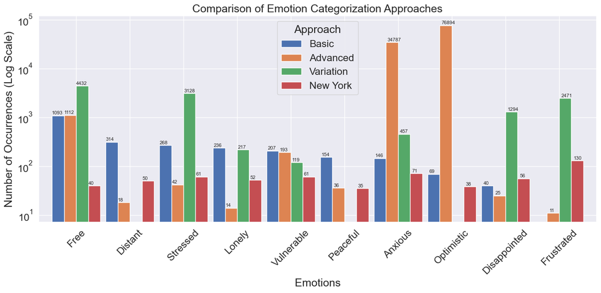

```python
# Creating a non-stacked bar chart with integer totals and custom color palette
plt.figure(figsize=(14, 7))
ax = emotion_comparison_df.plot(kind='bar', ax=plt.gca(), width=0.9)
plt.yscale('log')  # Setting y-axis to logarithmic scale

# Adding integer total counts on top of each bar with slight vertical offset for better visibility
for p in ax.patches:
    ax.annotate(f'{int(p.get_height())}', (p.get_x() * 1.005, p.get_height() * 1.05), fontsize=8)

plt.title('Comparison of Emotion Categorization Approaches')
plt.ylabel('Number of Occurrences (Log Scale)')
plt.xlabel('Emotions')
plt.xticks(rotation=45)
plt.legend(title='Approach')
plt.tight_layout()  # Adjust the plot to ensure everything fits without overlapping
plt.show()
```

### Checking the advanced results for the analysis in some tweets

```python
# Apply the filter
data_covid['advanced_emotions'].notna()

# Display the first 100 rows of the filtered data
data_covid.head(100)
```

|  | text | user_location | text_cleaned | polarity | subjectivity | sentiment | emotions | advanced_emotions | variation_emotions |
| --- | --- | --- | --- | --- | --- | --- | --- | --- | --- |
| 2 | @diane3443 @wdunlap @realDonaldTrump Trump never once claimed #COVID19 was a hoax. We all claim that this effort to… https://t.co/Jkk8vHWHb3 | pewee valley, ky | trump never once claimed covid19 was a hoax we all claim that this effort to | 0.00 | 0.000000 | neutral | [Optimistic] | [None] | [None] |
| 3 | @brookbanktv The one gift #COVID19 has give me is an appreciation for the simple things that were always around me… https://t.co/Z0pOAlFXcW | stuck in the middle | the one gift covid19 has give me is an appreciation for the simple things that were always around me | 0.00 | 0.357143 | neutral | [Optimistic] | [None] | [None] |
| 4 | 25 July : Media Bulletin on Novel #CoronaVirusUpdates #COVID19 \n@kansalrohit69 @DrSyedSehrish @airnewsalerts @ANI… https://t.co/MN0EEcsJHh | jammu and kashmir | 25 july media bulletin on novel coronavirusupdates covid19 \n | 0.00 | 0.000000 | neutral | [Optimistic] | [None] | [None] |
| 5 | #coronavirus #covid19 deaths continue to rise. It's almost as bad as it ever was. Politicians and businesses want… https://t.co/hXMHooXX2C | новоро́ссия | coronavirus covid19 deaths continue to rise its almost as bad as it ever was politicians and businesses want | -0.70 | 0.666667 | negative | [Optimistic] | [None] | [None] |
| 6 | How #COVID19 Will Change Work in General (and recruiting, specifically) via/ @ProactiveTalent #Recruiting… https://t.co/bjZxzGPMbK | gainesville, fl | how covid19 will change work in general and recruiting specifically via recruiting | 0.05 | 0.500000 | positive | [Optimistic] | [None] | [None] |
| ... | ... | ... | ... | ... | ... | ... | ... | ... | ... |
| 143 | Vietnam’s high level of preparedness to prevent Covid-19 spread: Deputy PM #Vietnam #covid19 #coronavirus #ncov… https://t.co/H2hJRzkEZl | hanoi, vietnam | vietnams high level of preparedness to prevent covid19 spread deputy pm vietnam covid19 coronavirus ncov | 0.16 | 0.540000 | positive | [Optimistic] | [None] | [None] |
| 145 | @CBCTheHouse @PattyHajdu @CochraneCBC #Covid19 Fatigue, people in front lines we cannot replace, that is #Fatigue!… https://t.co/8pk0Vik8gX | new brunswick, canada | covid19 fatigue people in front lines we cannot replace that is fatigue | 0.00 | 0.000000 | neutral | [Anxious] | [None] | [None] |
| 146 | We provided a North Devon tourist attraction with a digital #twowayradio solution even before #COVID19 struck. As w… https://t.co/kLwJHahlkq | exeter | we provided a north devon tourist attraction with a digital twowayradio solution even before covid19 struck as w | 0.00 | 0.000000 | neutral | [Optimistic] | [None] | [None] |
| 147 | Mask Print #1 (Londoners Wear Masks) https://t.co/N1zwBuf1No #MaskUp #mask #Masks #MaskMoaners #COVID19 #COVIDー19… https://t.co/W7uBNQomP2 | NaN | mask print 1 londoners wear masks maskup mask masks maskmoaners covid19 covidー19 | 0.00 | 0.000000 | neutral | [Anxious] | [None] | [None] |
| 148 | #RepublicansForBidenNow #COVID19 \nRepublican Group Uses Trump's Own Words Against Him In Searing Swing-State Ad… https://t.co/9fhivsvvHf | NaN | republicansforbidennow covid19 \nrepublican group uses trumps own words against him in searing swingstate ad | 0.60 | 1.000000 | positive | [Optimistic] | [None] | [None] |

100 rows × 9 columns